# Checking the Kaggle Stroke Data

### Check 17 - Are there implausible sequences in integers (after deleting decimals)?

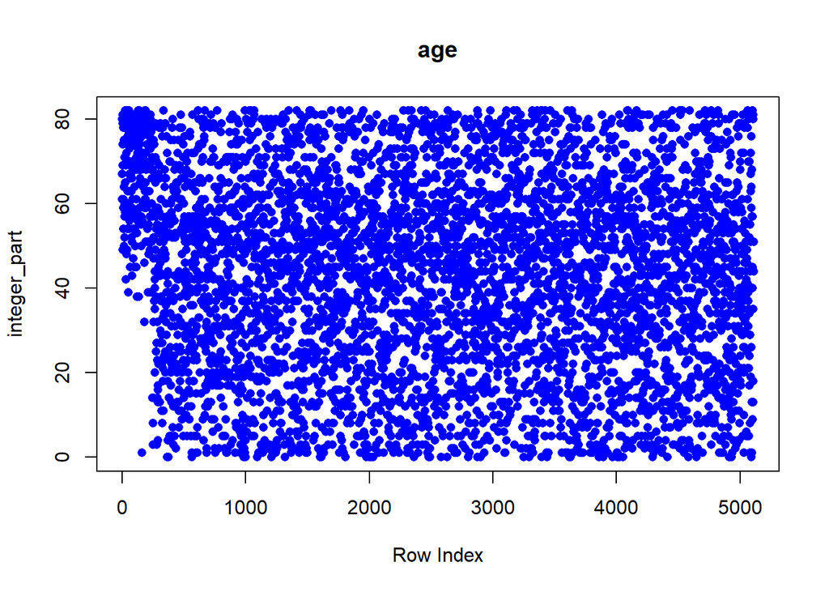

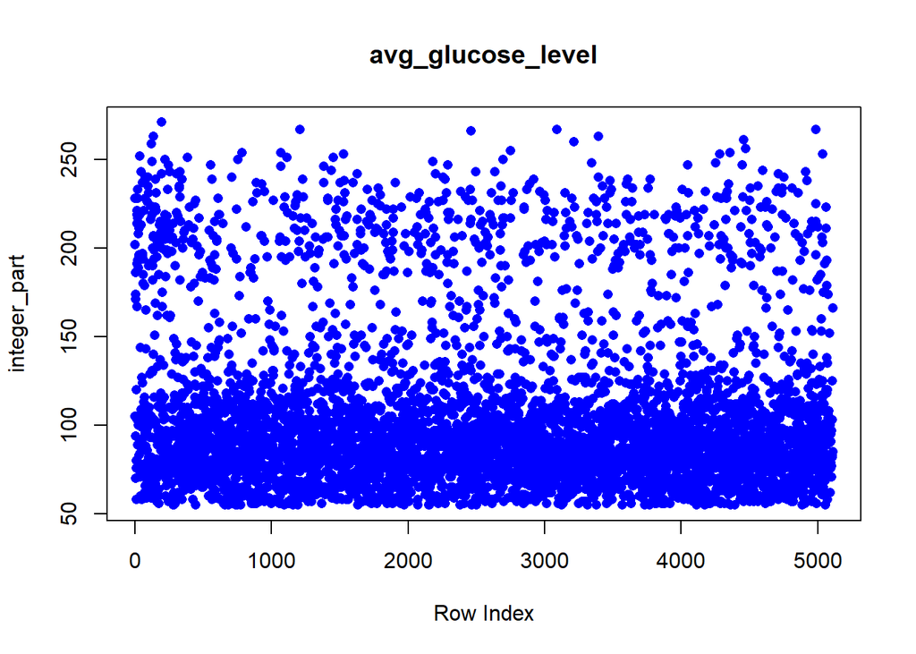

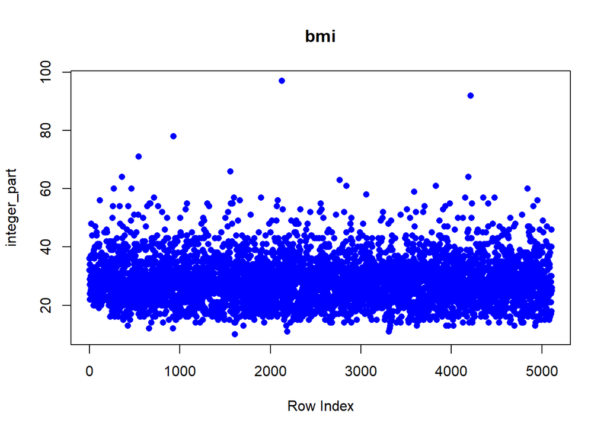

### Check 18 - Is there evidence of autocorrelation between successive observations in the dataset?

#### Overall analysis:

```
## Durbin-Watson Test Results (Overall):
```

```
##
##
## |Variable          | DW_Statistic| P_value|Autocorrelation  |
## |:-----------------|------------:|-------:|:----------------|
## |age               |        1.890|  0.0000|⚠️ Significant    |
## |avg_glucose_level |        1.949|  0.0332|⚠️ Significant    |
## |bmi               |        2.005|  0.5617|✅ None detected |
```

```
##
##
## Autocorrelation Function (ACF) Plots:
```

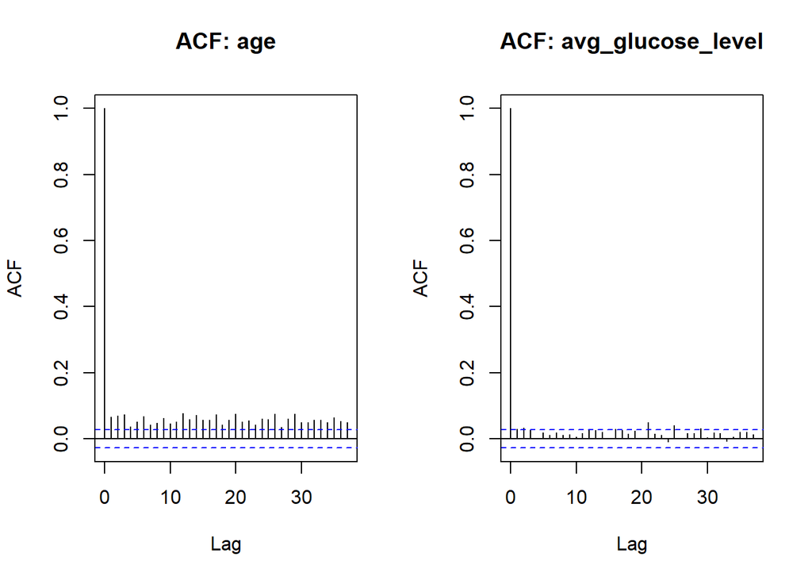

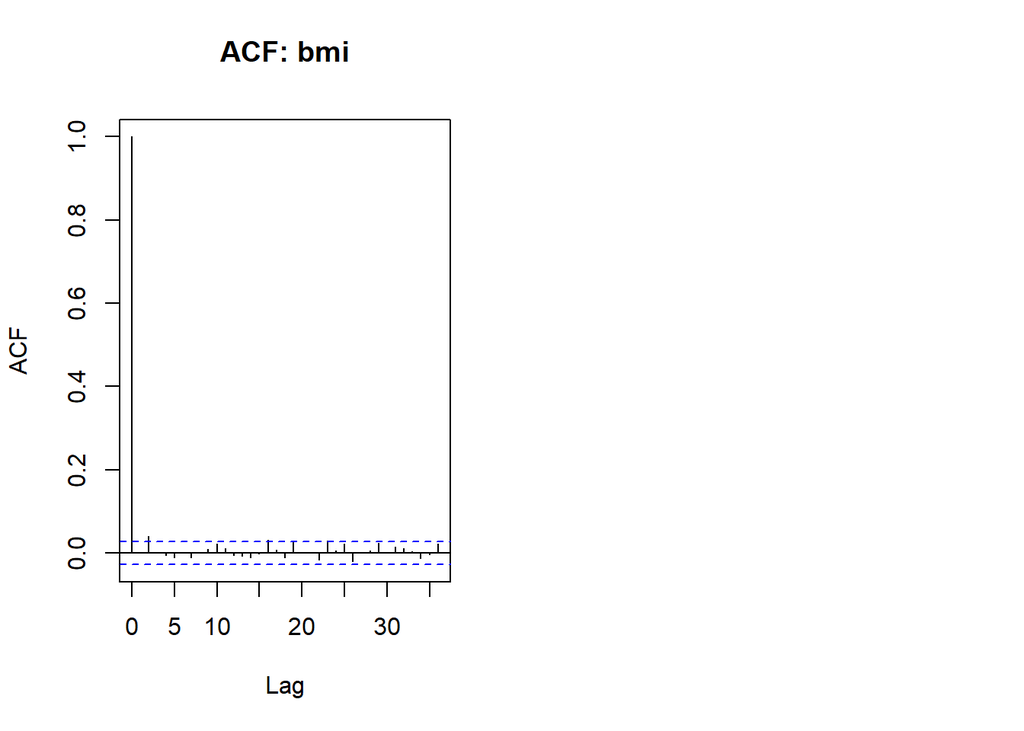

**Interpreting results:**  
- **Durbin-Watson statistic:** Values near 2 indicate no autocorrelation; <1.5 or >2.5 suggest autocorrelation  
- **ACF plots:** Spikes outside blue dashed lines = significant autocorrelation at that lag  
- **Expected:** Random pattern with most spikes within blue bounds  
- **Red flag:** Many consecutive spikes outside bounds, especially at early lags (1-5)  
**Important distinction:** The Durbin-Watson test examines autocorrelation in residuals after accounting for linear trends, while ACF plots show raw autocorrelation. Variables can show autocorrelation in ACF plots but pass the DW test if the pattern is explained by a time trend.

**Why this matters:** Fabricated data often shows autocorrelation when fabricators generate values based on previous values (e.g., “45, 46, 47…”) rather than independently sampling.

**Note on multicentre trials:**  
If the data comes from multiple centres this may inflate ACF values artificially, interpret with caution.

#### By study group:

```
## Durbin-Watson Test Results by Group:
```

```
##
##
## |Variable          |Group   | DW_Statistic| P_value|Autocorrelation |
## |:-----------------|:-------|------------:|-------:|:---------------|
## |age               |Group 1 |        1.985|  0.2929|✅ None         |
## |age               |Group 2 |        2.043|  0.6093|✅ None         |
## |avg_glucose_level |Group 1 |        2.005|  0.5605|✅ None         |
## |avg_glucose_level |Group 2 |        1.689|  0.0058|⚠️ Significant   |
## |bmi               |Group 1 |        2.002|  0.5234|✅ None         |
## |bmi               |Group 2 |        2.163|  0.8678|✅ None         |
```

```
##
##
## ACF Plots by Group:
```

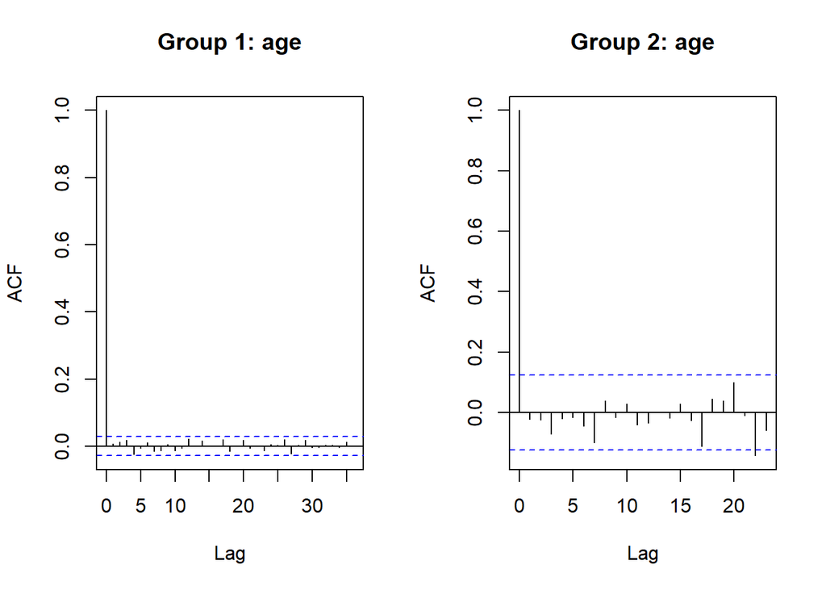

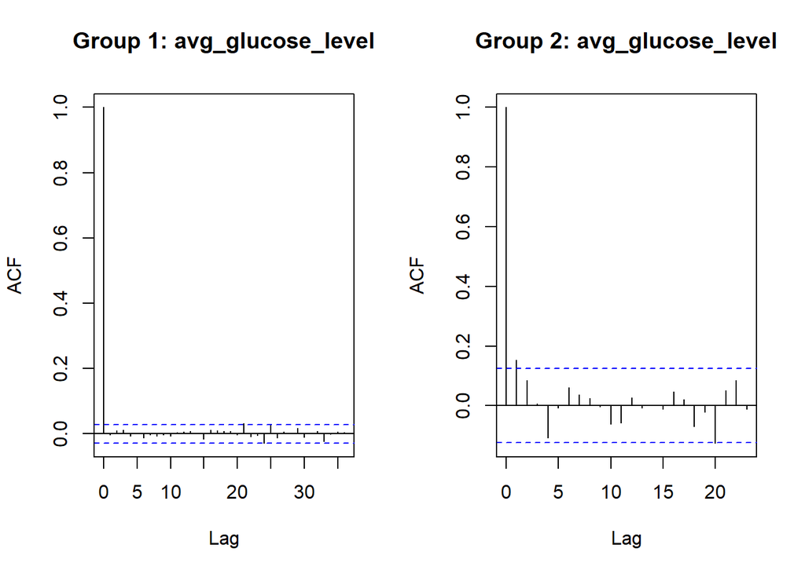

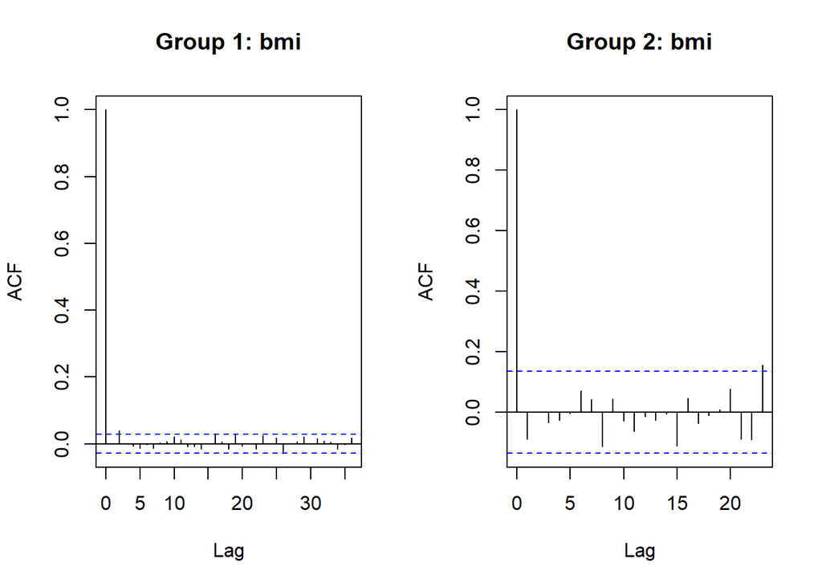

**Additional consideration:** If one group shows strong autocorrelation while the other doesn’t, this may indicate fabrication of only one arm’s data.

### Check 19 - When the dataset is ordered by participant ID or randomisation timestamp, does the N+1th participant have the same condition as the Nth 1/k of the time (where there are k conditions)?

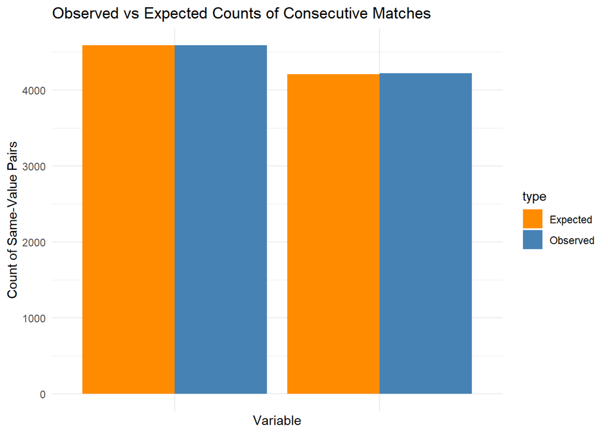

```
##
##
## ==============================
## SUMMARY TABLE
## ==============================
```

Consecutive Value Independence Tests

| Variable | Test | P_value |
| --- | --- | --- |
| hypertension | Chi-squared | 0.5824 |
| heart_disease | Chi-squared | 0.9804 |

**Interpretation**  
A p-value < 0.05 in this test suggests non-random ordering - specifically, that consecutive participants are too similar (or too different) compared to what you’d expect by chance.

## Domain 3 - Inspecting relationships between variables

### Check 20 - Can inliers be identified using singular value decomposition?

```
## Using 5110 complete cases (100.0% of dataset)
##
## ⚠️ Error in Greenacre analysis (All patients): Need at least 2 numeric columns.
## ⚠️ Error in Greenacre analysis (Group 1): Need at least 2 numeric columns.
## ⚠️ Error in Greenacre analysis (Group 2): Need at least 2 numeric columns.
## === Greenacre Inlier Detection (SVD-based) ===
```

**Interpretation:**  
“Inliers” are values that fit the multivariate pattern suspiciously well, suggesting possible data fabrication through imputation or copying. Multiple inlier flags for the same patient are particularly concerning and warrant investigation.

If the overall number of flagged cells (i.e. % flagged for “ALL PATIENTS”) is small it is suggested to conclude ‘no concerns’

**Key red flags:**  
• Large difference in flagging rates between groups  
• Same patient flagged multiple times

### Check 21 - Can inliers be identified using Mahalanobis distance?

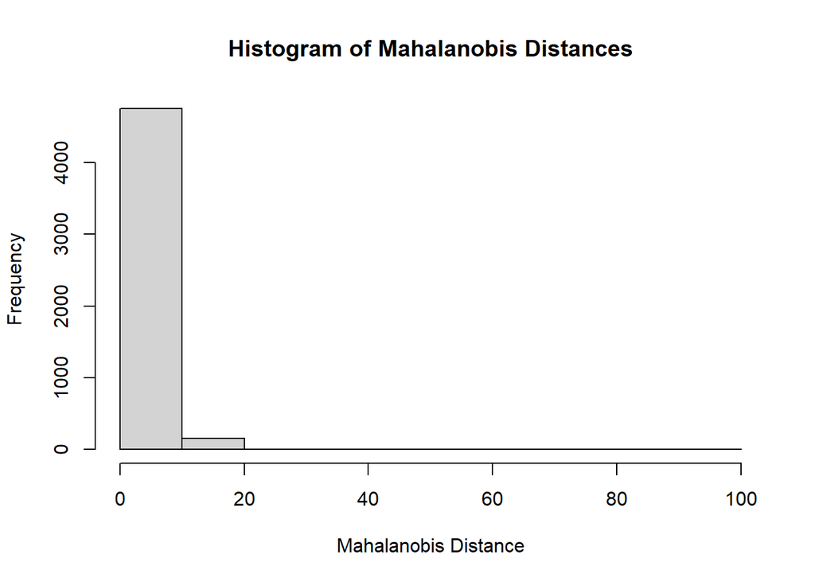

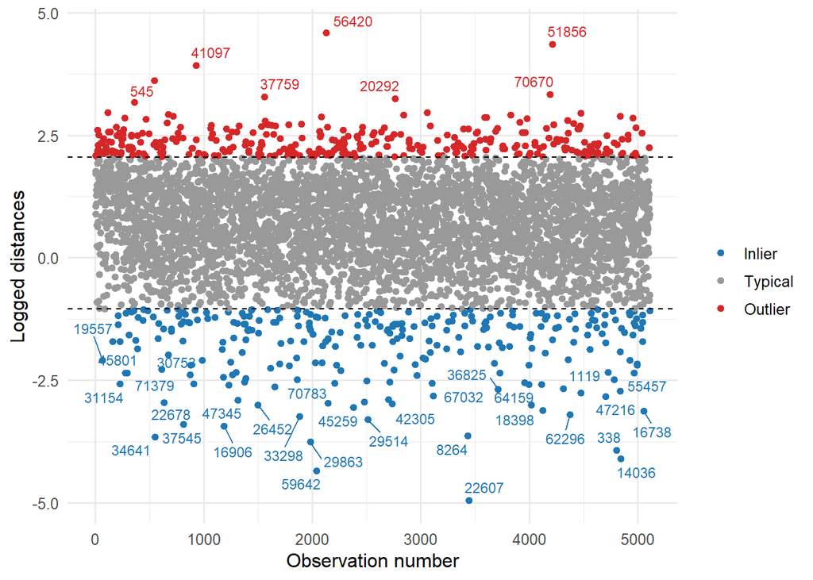

| id | age | avg_glucose_level | bmi | MD2 | near_mean_vars |
| --- | --- | --- | --- | --- | --- |
| 19557 | 45 ◀ | 93.72 | 30.2 | 0.1244 | age |
| 43054 | 50 | 102.16 ◀ | 31.4 | 0.1819 | avg_glucose_level |
| 33943 | 39 | 83.24 | 26.3 | 0.3081 |  |
| 62439 | 51 | 103.43 ◀ | 27.3 | 0.2566 | avg_glucose_level |
| 8899 | 49 | 104.86 ◀ | 31.9 | 0.1820 | avg_glucose_level |
| 31154 | 39 | 97.76 | 29.6 ◀ | 0.0764 | bmi |
| 45801 | 38 | 97.49 | 26.9 | 0.0956 |  |
| 29908 | 47 | 103.26 ◀ | 25.4 | 0.3228 | avg_glucose_level |
| 71379 | 45 ◀ | 113.63 | 27.5 | 0.0959 | age |
| 66174 | 46 ◀ | 88.19 | 29.3 ◀ | 0.2070 | age, bmi |
| 55232 | 38 | 79.83 | 27.9 ◀ | 0.3357 | bmi |
| 16934 | 51 | 89.84 | 29.9 ◀ | 0.3319 | bmi |
| 21284 | 32 | 98.09 | 25.2 | 0.3402 |  |
| 10159 | 41 ◀ | 99.80 ◀ | 31.6 | 0.1852 | age, avg_glucose_level |
| 13547 | 37 | 91.72 | 29.2 ◀ | 0.1568 | bmi |
| 44862 | 39 | 83.51 | 26.4 | 0.2962 |  |
| 67177 | 53 | 116.66 | 28.5 ◀ | 0.2783 | bmi |
| 65946 | 53 | 123.87 | 28.8 ◀ | 0.3476 | bmi |
| 3009 | 53 | 96.88 | 31.4 | 0.3398 |  |
| 26028 | 51 | 98.41 | 32.1 | 0.3025 |  |
| 34641 | 40 ◀ | 100.35 ◀ | 28.1 ◀ | 0.0261 | age, avg_glucose_level, bmi |
| 24592 | 51 | 109.16 ◀ | 28.0 ◀ | 0.1925 | avg_glucose_level, bmi |
| 32437 | 54 | 107.47 ◀ | 29.3 ◀ | 0.2613 | avg_glucose_level, bmi |
| 30753 | 42 ◀ | 93.79 | 27.2 | 0.1034 | age |
| 5353 | 52 | 101.50 ◀ | 31.2 | 0.2345 | avg_glucose_level |
| 22678 | 42 ◀ | 97.78 | 29.8 ◀ | 0.0525 | age, bmi |
| 10997 | 38 | 98.73 ◀ | 24.3 | 0.3443 | avg_glucose_level |
| 66184 | 40 ◀ | 100.26 ◀ | 26.0 | 0.1382 | age, avg_glucose_level |
| 58767 | 37 | 91.45 | 25.8 | 0.2242 |  |
| 13997 | 38 | 88.97 | 30.2 | 0.2363 |  |

[output cut: 243 more lines]

**Interpretation:**  
The table shows observations identified as “inliers”. If the data follows a multivariate normal distribution this may flag around 5% of cases., meaning their values across all continuous variables are closest to the group means.

- **◀ marker:** Indicates individual cells where the value is extremely close to the mean (within 0.15 standard deviations)
- **near_mean_vars column:** Lists which variables were flagged with the ◀ marker for each inlier
- **MD2 column:** The squared Mahalanobis distance - lower values indicate more similarity to the group mean across all variables

**What to look for:** While 5% of observations will always be flagged as inliers, the concern is whether these inliers show *suspiciously many* values close to the mean (many ◀ markers). Fabricated data may show inliers with implausibly consistent values across multiple measurements, whereas genuine inliers typically have only a few variables close to the mean.

### Check 22 - Does examining relationships between variables suggest biological/contextual implausibility (e.g. by plotting against each other)?

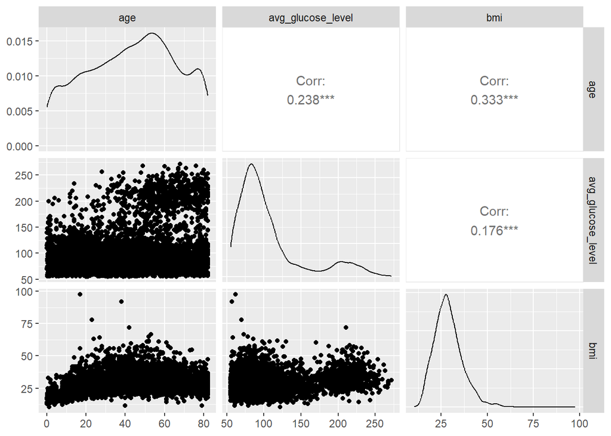

### Check 23 - Do statistical tests that compare multivariate correlations between variables show differences between study groups?

#### There are three different methods to consider for this, Jennrich, Mantel or HD test

```
##
##
## Table: Tests for Correlation Matrix Equality Between Groups
##
## |Test     |Statistic   | P_value|Interpretation   |
## |:--------|:-----------|-------:|:----------------|
## |Jennrich |χ² = 119.82 |       0|⚠️ Different      |
## |Mantel   |r = -1.000  |       1|⚠️ Weak alignment |
## |HD       |9.07        |       0|⚠️ Different      |
```

**INTERPRETATION**

In genuine randomisation: correlation structures should be SIMILAR between arms In fabricated data: correlations may differ if fabricator doesn’t maintain multivariate relationships consistently across groups

JENNRICH TEST H0: Correlation matrices are equal between groups  
- Small p-value (< 0.05) → REJECT equality → RED FLAG for fabrication  
- Large p-value → correlation structures are similar → consistent with genuine data  
- Most powerful test for low-dimensional data (p < 20 variables typically)

MANTEL TEST Tests whether correlation patterns are aligned between groups  
- Statistic r: correlation between the two correlation matrices  
* r close to +1 → highly similar patterns → consistent with genuine data  
* r close to 0 → unrelated patterns → POSSIBLE red flag  
* r close to -1 → opposite patterns → STRONG red flag  
- p-value tests alignment (one-sided by default in this setup)  
* High p when r is negative → no evidence of positive alignment  
* **p < 0.05 with low r (<0.5) → correlation structures are significantly misaligned between groups → RED FLAG for fabrication**

HD TEST (HDtest::testCov on z-scored data)  
H0: Correlation matrices are equal between groups (normally tests for covariance matrices but we standardised first), does this a different way to Jennrich though  
- Interpretation same as Jennrich  
- Designed for high-dimensional data (large p)  
- Less powerful than Jennrich for low p  
- Good cross-check but defer to Jennrich if they disagree in low dimensions

### Check 25 - Does plotting Star Plots for each group reveal any unusual patterns or differences?

```
##
## === Group 2 ===
```

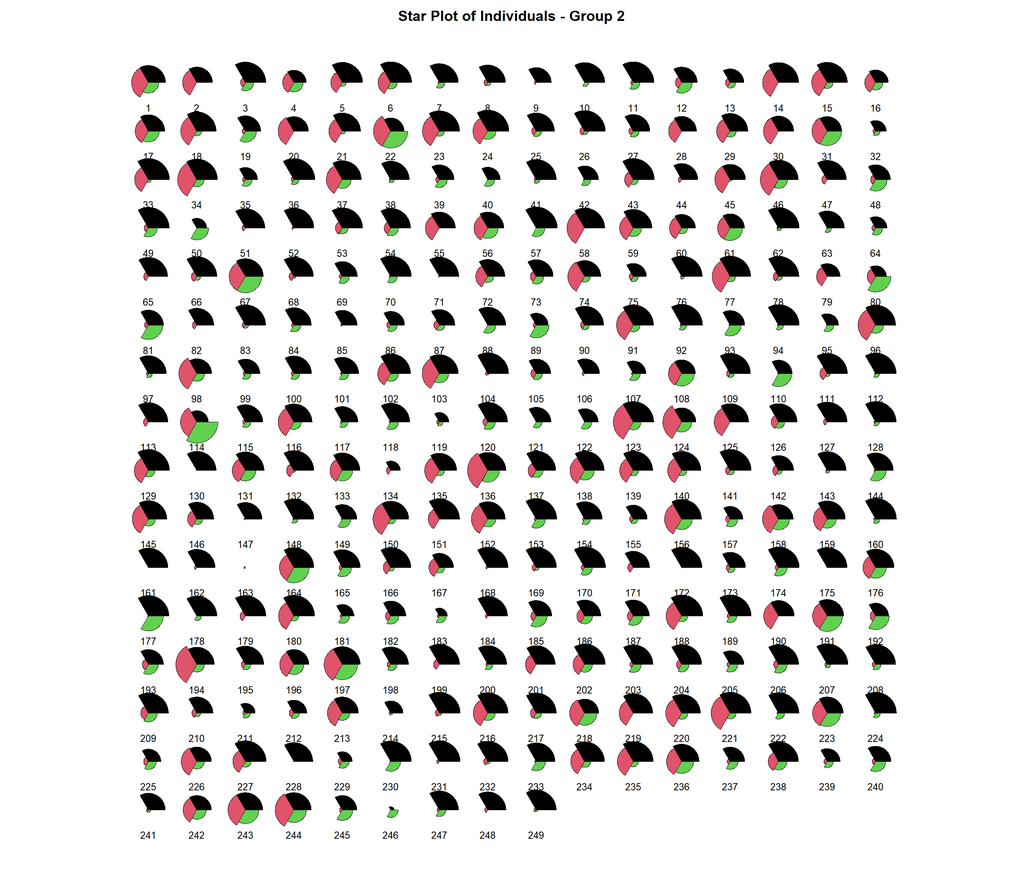

```
##
## === Group 1 ===
```

[figure not shown]

**Interpretation:**  
Star plots display each observation as a star shape, where each ray represents a different variable’s value. Look for:  
- **Unusual similarity of star shapes** within a group, suggesting insufficient natural variation  
- **Identical or near-identical stars**, indicating potential duplication  
- **Regular geometric patterns** (e.g., all stars having similar proportions), which may suggest systematic fabrication

Genuine data typically shows diverse star shapes even within groups. If >15 variables, we automatically select the 12 most interconnected variables since fabricators typically struggle most with maintaining these multivariate relationships.

### Check 26 - Does applying a neighbourhood clustering method (i.e. of Wu and Carlsson) reveal unusual/unexpected clustering?

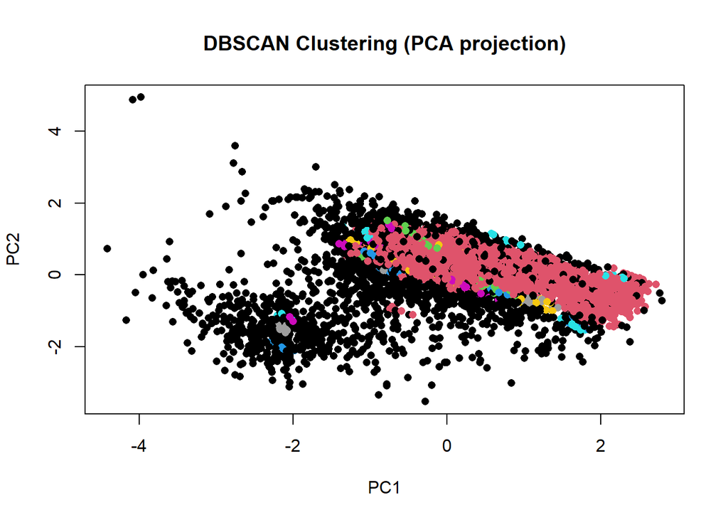

```
##
## Cluster summary:
## Number of clusters found: 49
## Number of noise points: 1964
##
##    0    1    2    3    4    5    6    7    8    9   10   11   12   13   14   15
## 1964 2571   25   10   14   10   12    8    6    8   10   11   10    5    7    5
##   16   17   18   19   20   21   22   23   24   25   26   27   28   29   30   31
##    7    7   25    9    6    8    6   14    5    6    5    1    5    6   10    6
##   32   33   34   35   36   37   38   39   40   41   42   43   44   45   46   47
##   15    7    5    6    5    7    8    4    5    7    4    5    5    5    5    5
##   48   49
##    4    5
```

**Interpretation:**  
DBSCAN identifies clusters of densely-packed observations. In fabricated data, you may see:  
**Unexpected geometric patterns** (parallel lines, regular spacing, diagonal bands)  
**Multiple distinct clusters** where random allocation should produce one cloud

If more than one cluster is found - this could indicate:  
• Systematic patterns in data generation  
• Copy-paste duplication with slight modifications  
• Non-random participant allocation

If only a single cluster is found, this is consistent with genuine data variation.  
If no clusters are detected (only noise points detected) - data may be too sparse or parameters need adjustment.

#### Comparing between groups with dendrograms

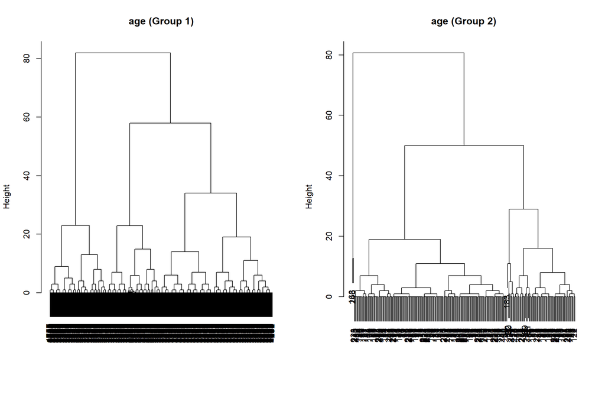

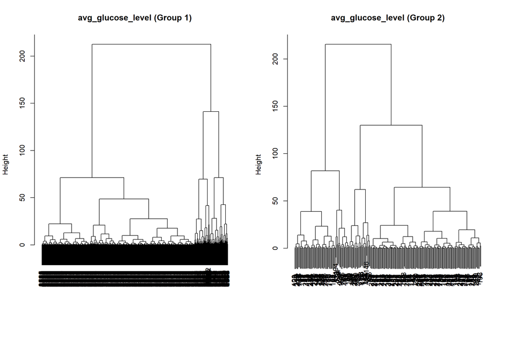

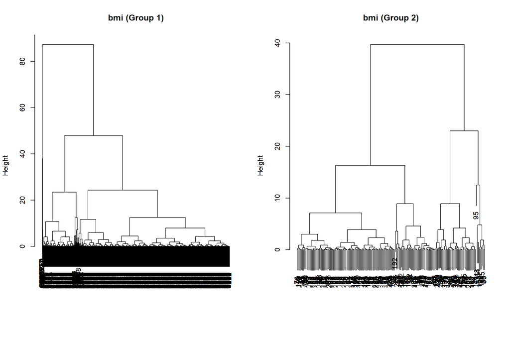

**Interpreting dendrograms:**

1. **Bottom of plot (height = 0):** Each vertical line is one participant
2. **Moving upward:** Lines merge to form branches representing groups of participants
3. **Height of merger:** Shows how different the values are:
   - Merge at height ≈ 0 → Nearly identical values
   - Merge at height > 5 → Very different values

**In genuine data, expect:** - ✅ Relatively uniform branch heights (no obvious clusters) - ✅ Random grouping patterns - ✅ Gradual increases in height as you move up the tree

**Red flags for fabrication:** - ⚠️ **Dense clustering at height = 0:** Multiple participants with identical values (unusual for continuous variables with decimal places) - ⚠️ **Distinct separated clusters:** Clear gaps suggest systematic generation (e.g., “group 1 gets values 5-6, group 2 gets values 7-8”) - ⚠️ **Different patterns between study groups:** One group clusters differently than the other

**Important caveat:** For **integer variables** (e.g., age in whole years), some clustering at height = 0 is normal and expected - multiple participants naturally share the same value. Dense clustering is only suspicious for **continuous variables with decimal places** (e.g., blood pressure measured to 0.01 mmHg precision, where identical values are unlikely by chance).

**Example:** - Age = 45 for 10 participants → **Normal** (integer variable) - Systolic BP = 127.384 for 10 participants → **Suspicious** (high-precision continuous variable)

**Why this matters:** Fabricators often create data by copying and modifying values, or by systematically generating sequences, both of which create artificial clustering patterns not seen in genuine measurements.

### Check 27 - Are any variables a subset of a second variable within a data set?

```
##
##
## ### Stage 2: Shift detection skipped
##
## No suspicious pairs identified in Stage 1, so shift detection not needed.
```

**Interpreting Check 27: Two-Stage Copy Detection**

**Overview:**  
This check uses a two-stage approach to detect copy-paste fraud:  
- **Stage 1:** Identifies pairs of variables that are suspiciously similar  
- **Stage 2:** Tests suspicious pairs to determine if one is a shifted copy of the other

#### **Stage 1: Direct Similarity Detection**

**What this checks:** Whether two variables have unusually similar **raw values** (not just correlation). This detects direct copying where a fabricator duplicated a column with minimal changes.

**The statistics:** - **obs_stat:** Mean absolute difference between the two variables (lower = more similar) - **p_value:** Probability of seeing this level of similarity by chance when variables are independent

**When Stage 1 flags a pair (p < 0.05):** ✅ **Legitimate reasons:** - Measurement error led to recording same value in multiple fields - Variables measured on same scale with restricted range (e.g., both percentages 0-100) - Pre/post measures of same construct with minimal change

⚠️ **Suspicious patterns:** - **Theoretically independent variables showing near-identical values** - **Variables on different scales showing low MAD** (shouldn’t be possible unless copied) - **Multiple pairs flagged** (systematic copying pattern)

**Example interpretations:** - `height_cm` and `weight_kg` with obs_stat = 2.3, p = 0.04 → **Suspicious** (different units, shouldn’t have similar raw values) - `baseline_score_T1` and `baseline_score_T2` with obs_stat = 0.1, p = 0.001 → **Investigate** (possibly duplicate measurement)

#### **Stage 2: Shifted Copy Detection**

**What this checks:** For pairs flagged in Stage 1, this tests whether the similarity is due to one variable being a **row-shifted copy** of the other. Detects copy-paste errors where data was pasted with a row offset.

**The statistics:** - **best_lag:** How many rows variable 2 was shifted to achieve minimum difference - **best_lag = 0:** Variables align without shifting (direct copy) - **best_lag > 0:** Variables are most similar when shifted by this many rows - **min_mad:** Minimum mean absolute difference across all possible shifts - **p_value:** Probability of finding this minimum MAD by chance

**Critical interpretation:**

🚩 **RED FLAG - Strong evidence of fabrication:** - **best_lag > 0 with p < 0.05:** One variable appears to be a shifted copy of the other - This is **extremely unlikely** to occur naturally - Suggests fabricator copied data then sorted/reordered the dataset - Example: `age` and `sys_bp` most similar when age shifted 15 rows → **clear fabrication**

✅ **Less concerning:** - **best_lag = 0 with p < 0.05:** Variables are similar in their original alignment - Still suspicious from Stage 1, but no evidence of row manipulation - Could be duplicate measurement or legitimate repeated value - Requires domain knowledge to interpret

**Why best_lag > 0 is damning:** In a properly collected dataset, there’s **no legitimate reason** why shifting one variable’s rows would make it more similar to another variable. This pattern specifically indicates: 1. Column was copied from another variable 2. Dataset was sorted differently between variables 3. Data were fabricated, not collected from real participants

**Example:**

```
Stage 2 Results:
Variable 1: participant_age
Variable 2: systolic_bp
best_lag: 12
min_mad: 3.2
p_value: 0.003
Interpretation: Shifted copy (lag = 12 rows)
```

**This means:** When you shift systolic_bp up by 12 rows, it becomes very similar to age. This is **impossible** in real data and indicates fabrication.

#### **How to Use These Results:**

**Step 1:** Review Stage 1 flagged pairs - Use domain knowledge to identify which pairs *shouldn’t* be similar - Expect some false positives from legitimate measurement patterns

**Step 2:** Focus on Stage 2 results - **Any pair with best_lag > 0 and p < 0.05 is highly suspicious** - This is strong evidence of fabrication requiring investigation - best_lag = 0 pairs need contextual interpretation

**Step 3:** Look for patterns - Multiple shifted copies → systematic fabrication - Specific variables repeatedly involved → investigate those columns - Clustering of suspicious pairs → potential fabricated subset

#### **What This Test Does NOT Detect:**

❌ Natural correlation between variables (e.g., height and weight) - These have correlation but NOT similar raw values - Stage 1 tests raw similarity, not correlation

❌ Linear transformations that change scale - If one variable is 2×another +5, MAD will be high - This test catches near-identical copies, not scaled copies

❌ Randomly fabricated data - Only detects lazy copying, not sophisticated fabrication

### Check 28 - Is there evidence of abnormally low within person variability?

```
## No repeated measure variables found (variables starting with 'repeated_measure_').
## Skipping within-person variability analysis.
```

### Check 29 - Is there evidence within repeated measures of interpolation and duplication??

```
## No repeated measure variables found (variables starting with 'repeated_measure_').
## Skipping interpolation and duplication analysis.
```

### Check 30 - Does applying principal component analysis reveal abnormal loading on the first component?

```
## ℹ Using 4909 complete cases out of 5110 total (96.1% complete)
```

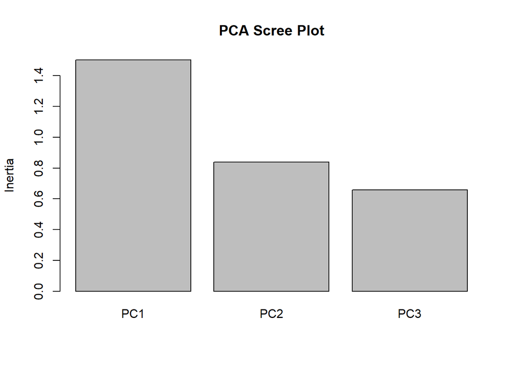

```
## ℹ Using 4909 complete cases out of 5110 total (96.1% complete)
##
## Principal Component Analysis - Variance Explained:
##
##
##
## |Component | Std Dev| Variance| Prop. Variance| Cumulative Prop.|
## |:---------|-------:|--------:|--------------:|----------------:|
## |PC1       |   1.226|    1.502|          0.501|            0.501|
## |PC2       |   0.916|    0.839|          0.280|            0.781|
## |PC3       |   0.811|    0.658|          0.219|            1.000|
```

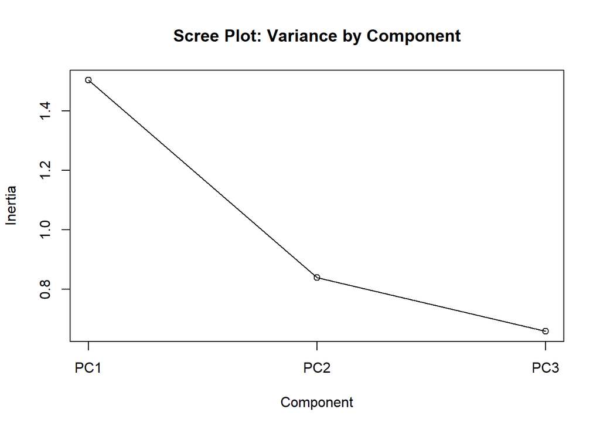

**Interpreting PCA results:**

**Proportion of Variance:** - Shows how much of the total variability each component explains - First few components typically explain most variance

**Cumulative Proportion:** - Running total of variance explained - Often aim for 70-80% cumulative variance with first few components - Helps decide how many components to retain

**Red flags for fabrication:** - ⚠️ **One PC dominates** (>80% variance explained (Prop. Variance >0.8)): Variables may be too similar/correlated (possible systematic generation) - ⚠️ **All PCs equally important** (flat scree plot): Unusual structure, may indicate artificial data

**Expected pattern:** Gradual decrease in variance explained (elbow shape in scree plot).

## Domain 4 - Inspecting digit/variable distribution

### Check 31 - Does examination of leading digits suggest violation of Benfords Law?

#### Magnitude span of variables:

```
## age                       Range: [0.08, 82.00]  Orders of magnitude: 3.01
## avg_glucose_level         Range: [55.12, 271.74]  Orders of magnitude: 0.69
## bmi                       Range: [10.30, 97.60]  Orders of magnitude: 0.98
```

#### Unless you have orders of magnitude here which are ≥ 2, **skip to next check**

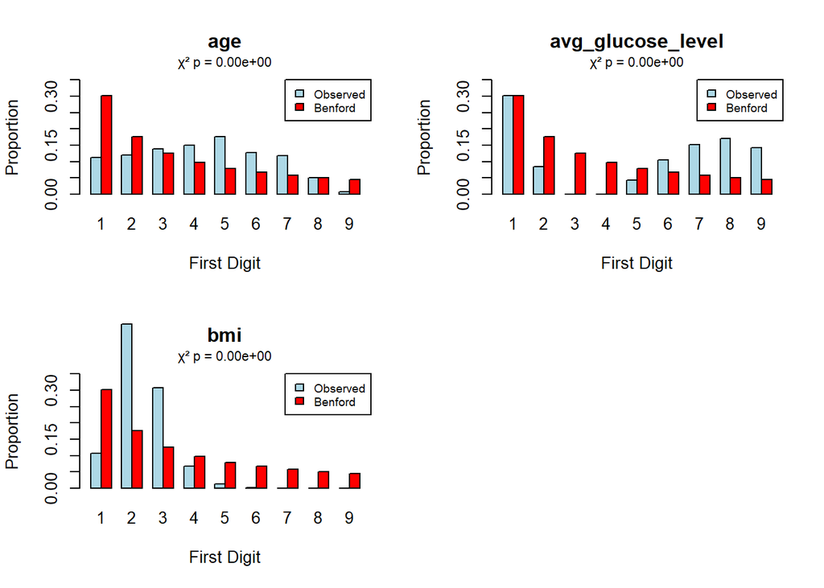

### Check 32 - Do non-first digits deviate from expected under Benfords Law?

```
##
## Chi-square results for tests of uniformity of digit frequencies
## ================================================================
##
## Variable             Place      Number     Chi-square   D.F.     Probability
## --------------------------------------------------------------------------------
## age                  Place 4    0          0.00         0        0.000000
## age                  Place 3    0          0.00         0        0.000000
## age                  Place 2    60         10.67        9        0.299251
## age                  Place 1    4745       20.80        9        0.013560
## age                  Total      4805       21.00        9        0.012650
##
## Digit frequency distribution (all places combined):
## Digit:     0   1   2   3   4   5   6   7   8   9
## Count:   501 522 529 461 466 443 439 458 516 470
```

[output not shown]

[output not shown]

```
##
## **Terminal Digit (Place 1) Distributions:**
```

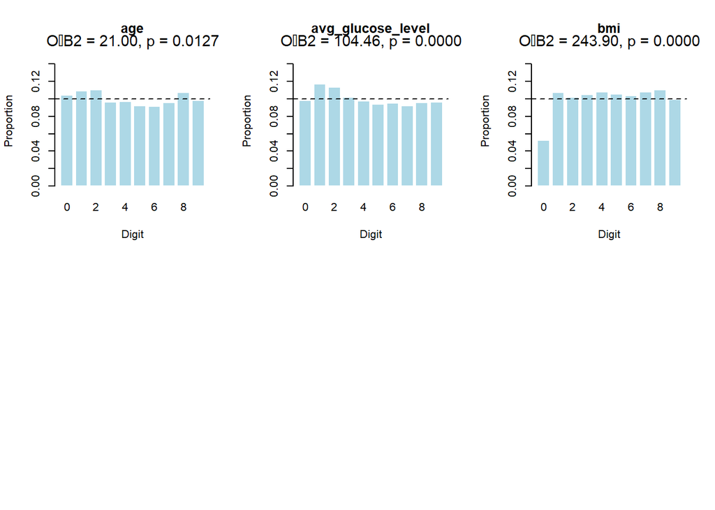

**Interpretation**  
For each variable the chi-square test of uniformity is carried out on ‘Place’ 1-4 (if applicable).  
Place here refers to position in the number, Place 1 refers to the rightmost (terminal) digit. Place 2 refers to the 2nd rightmost digit, etc. ‘Total’ tests all non-leading digits combined. In each case a p-value <0.05 suggests non-uniformity (a digit, or digits, appearing more or less frequently than we would expect). The plots are for ‘Place 1’ digits only.

### Check 33 - Do distributions of leading digits in baseline variables differ between randomised arms?

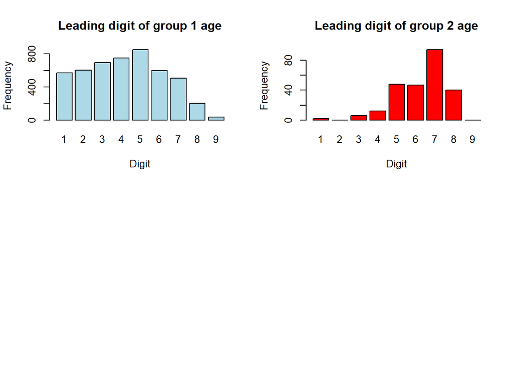

#### And doing Fishers Exact test:

```
##
##
## Table: Fisher's Exact Test: Leading Digit Distribution by Group
##
## |Variable | P_Value|
## |:--------|-------:|
## |age      |   1e-04|
```

### Check 34 - Do distributions of non-leading digits differ between randomised arms?

#### Right-most digit

```
##
## TERMINAL DIGIT COMPARISON BETWEEN GROUPS
## =========================================
##
##
##
## Variable    G1_n   G1_ChiSq     G1_p   G2_n   G2_ChiSq     G2_p   Fisher_p
## ---------  -----  ---------  -------  -----  ---------  -------  ---------
## age         4496      16.46   0.0579    249       31.2   0.0003      0.002
##
## Interpretation:
## - Group Chi-square p < 0.05: Digits deviate from uniformity (suspicious)
## - Fisher's p < 0.05: Digit distributions differ between groups
```

#### Second right-most digit

```
##
## TERMINAL DIGIT COMPARISON BETWEEN GROUPS
## =========================================
##
##
##
## Variable    G1_n   G1_ChiSq    G1_p   G2_n   G2_ChiSq     G2_p   Fisher_p
## ---------  -----  ---------  ------  -----  ---------  -------  ---------
## age           59      10.32   0.325      1          9   0.4373          1
##
## Interpretation:
## - Group Chi-square p < 0.05: Digits deviate from uniformity (suspicious)
## - Fisher's p < 0.05: Digit distributions differ between groups
```

#### Third right-most digit

```
## ⚠️ Third rightmost digit analysis not viable
```

#### Fourth right-most digit

```
## ⚠️ Fourth rightmost digit analysis not viable
```

### Check 35 - Do the distributions of single variables follow simple but implausible models(such as Normal)?

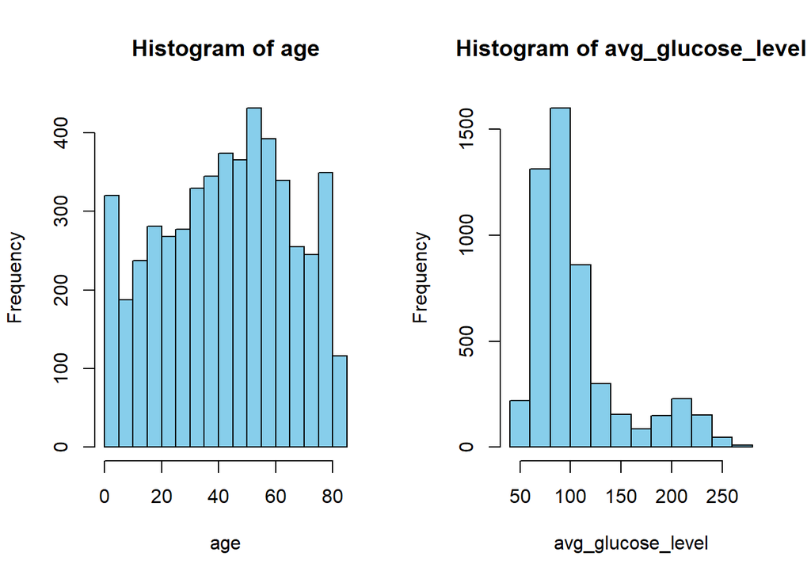

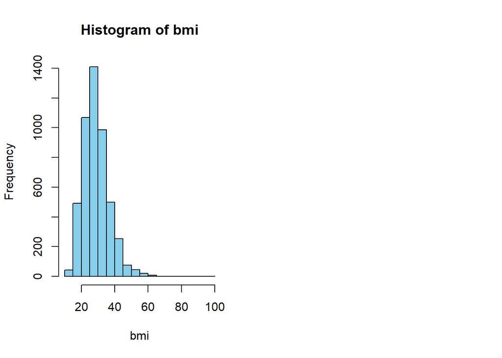

### Check 36 - Is there a detectable round number preference/excess of round numbers?

```
##
##
## Table: Terminal Digit Analysis Results
##
## |Variable          | Fisher_P| Group1_ChiSq| Group1_P| Group2_ChiSq| Group2_P|
## |:-----------------|--------:|------------:|--------:|------------:|--------:|
## |age               |   0.0025|        16.46|   0.0579|        31.20|   0.0003|
## |avg_glucose_level |   0.0610|       527.76|   0.0000|        46.06|   0.0000|
## |bmi               |   0.3843|       432.34|   0.0000|        27.70|   0.0011|
##
## **Interpretation:**
## - Fisher P: Tests if digit distributions differ between groups
## - Group Chi-Sq/P: Tests if each group's digits deviate from uniformity
## - Low p-values (< 0.05) suggest non-random digit patterns
```

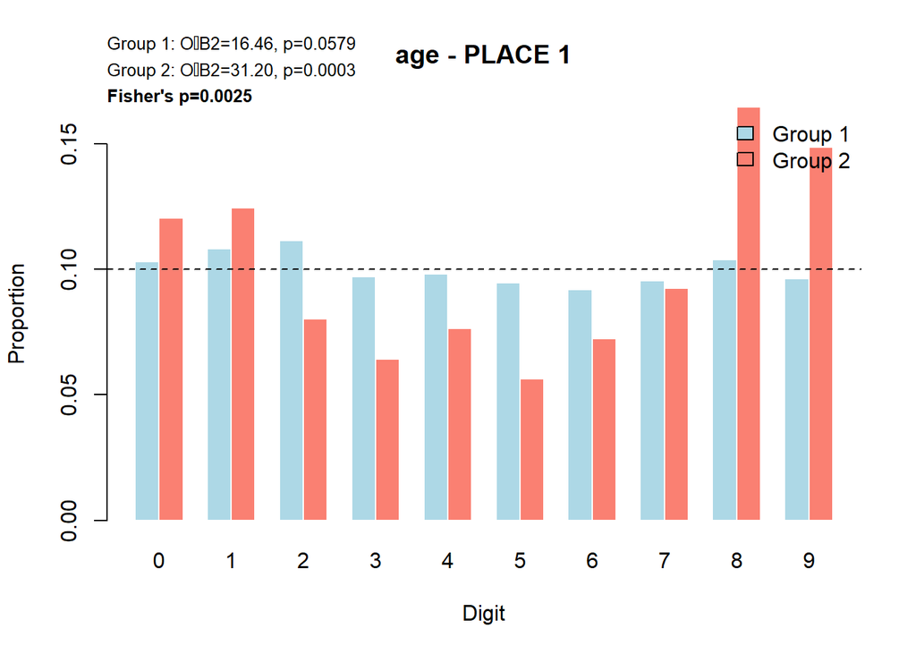

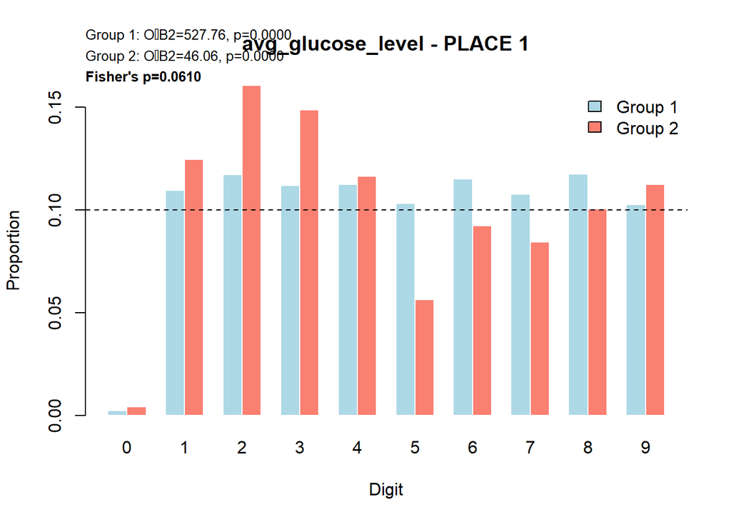

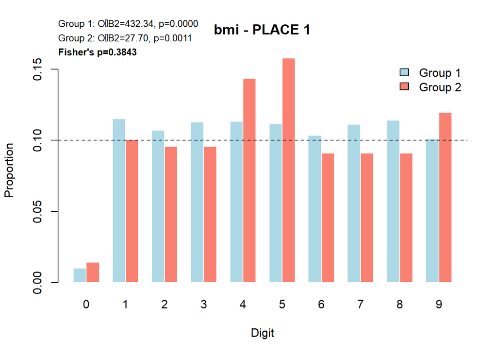

**Interpretation**  
These are the same results from Check 34, though just for the final digits (‘PLACE 1’). Here focus on whether, for any variables with a significant result, there is an excess of 0 or 5s.

### Check 37 - Do the frequency of digits suggest violation of Zipf’s law?

```
## Summary of variables for Zipf's Law analysis:
```

```
##
##
## |Variable | Unique Values|Range |Most Common | Frequency|Reliability |
## |:--------|-------------:|:-----|:-----------|---------:|:-----------|
```

```
##
## **Note:** Zipf's Law analysis is most reliable with >50 unique values.
```

**Interpreting Zipf’s Law plots:**

**Expected patterns in genuine data:** - ✅ Red points roughly follow one of the black reference lines - ✅ Approximate straight line on log-log plot - ✅ Gradual decline in frequency as rank increases

**Red flags for fabrication:** - ⚠️ **Points deviate systematically from all reference lines:** Data don’t follow natural distribution  
- ⚠️ **Sharp changes in slope:** Sudden jumps or breaks suggest artificial generation  
- ⚠️ **Too perfect alignment:** Exactly following s=1.0 line may indicate algorithmic generation  
- ⚠️ **Flat or irregular pattern:** No clear power-law relationship suggests non-natural data

**Important caveats:**

1. **Small sample sizes:** With <50 unique values, Zipf’s Law may not apply reliably (check table above)
2. **Limited range:** Variables with narrow ranges may not show Zipf behavior
3. **Categorical vs continuous:** Zipf’s Law applies best to integer/categorical data, not continuous measurements
4. **Context matters:** Not all variables should follow Zipf’s Law

**For this dataset:**  
Refer to the summary table above to assess whether each variable has sufficient unique values for meaningful Zipf analysis. Variables with <50 unique values should be interpreted with caution. Variables deemed to have ‘insufficient’ reliability have not had graphs produced for them.

**Why this matters:** Fabricators sometimes generate data using simple algorithms or patterns that create unnatural frequency distributions. However, many legitimate clinical variables won’t follow Zipf’s Law, so use this check alongside other evidence.

### Check 38 - Are there an implausible number of outliers detectable? (using graphical or other methods)

#### Tally of total outliers per variable

```
##            Variable Count
## 1               age     0
## 2 avg_glucose_level   627
## 3               bmi   110
```

#### All box plots

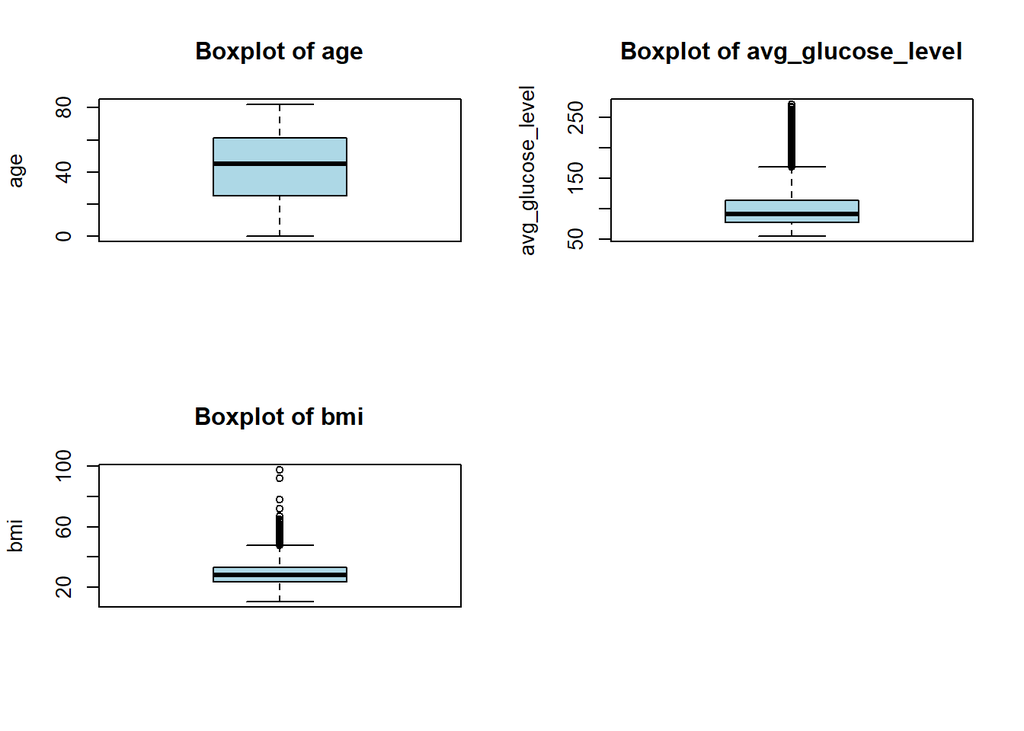

### Check 39 - Are unexpected peaks in variable distribution evident?

#### See results of Check 35 for all variable histograms (both groups together).

#### The following are the baseline variables, separated by group:

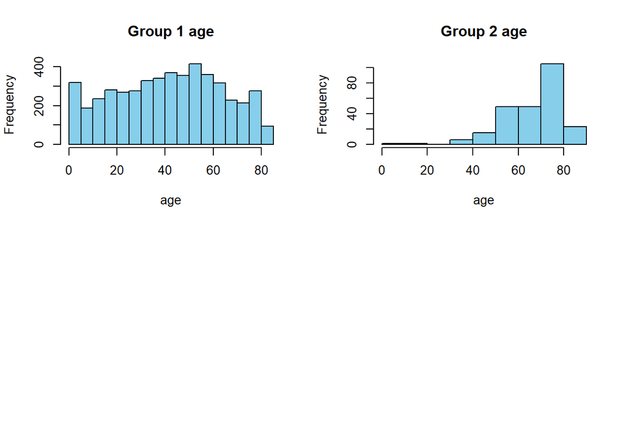

### Check 40 - Are variables skewed beyond expectation?

#### See results of Check 35

### Check 41 - Is there too little or too much variance?

```
## Two-tailed (+1 adj): 0
```

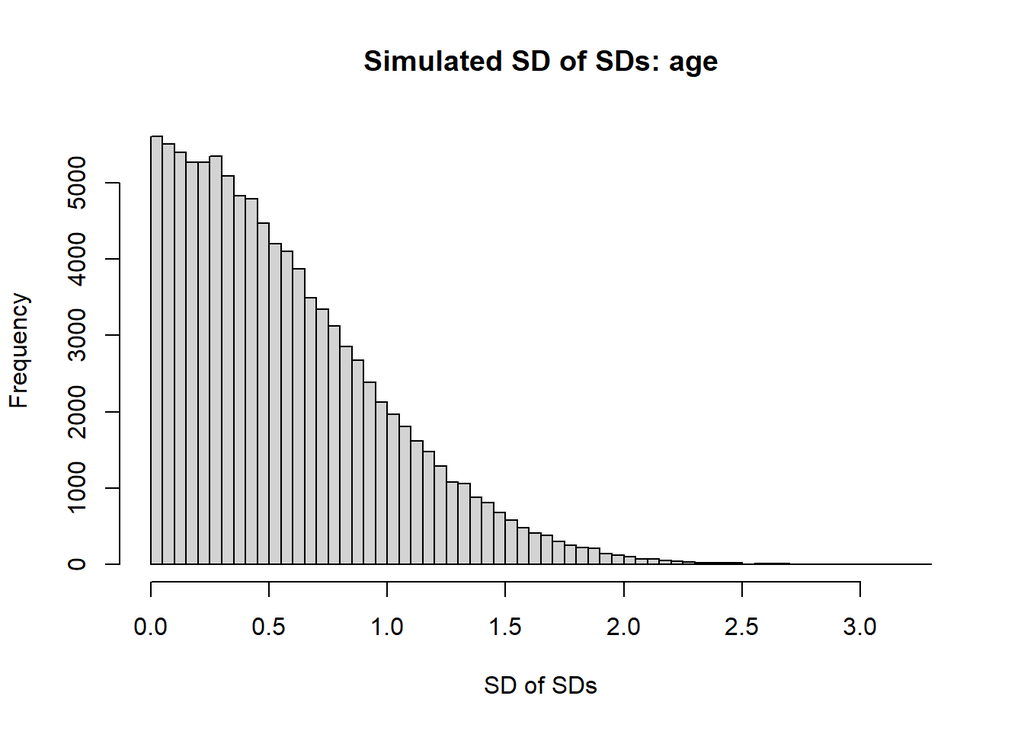

```
## Two-tailed (+1 adj): 0
```

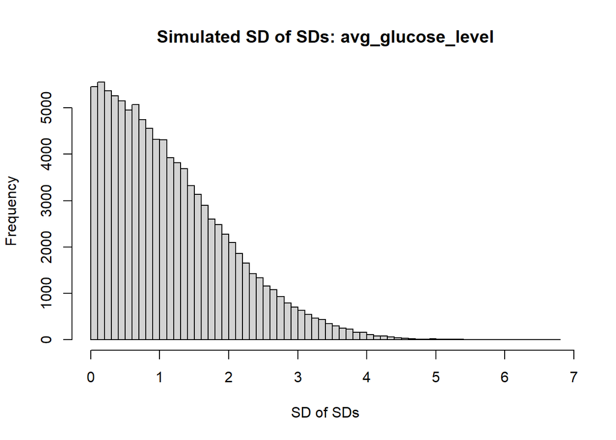

```
## Two-tailed (+1 adj): 1e-04
```

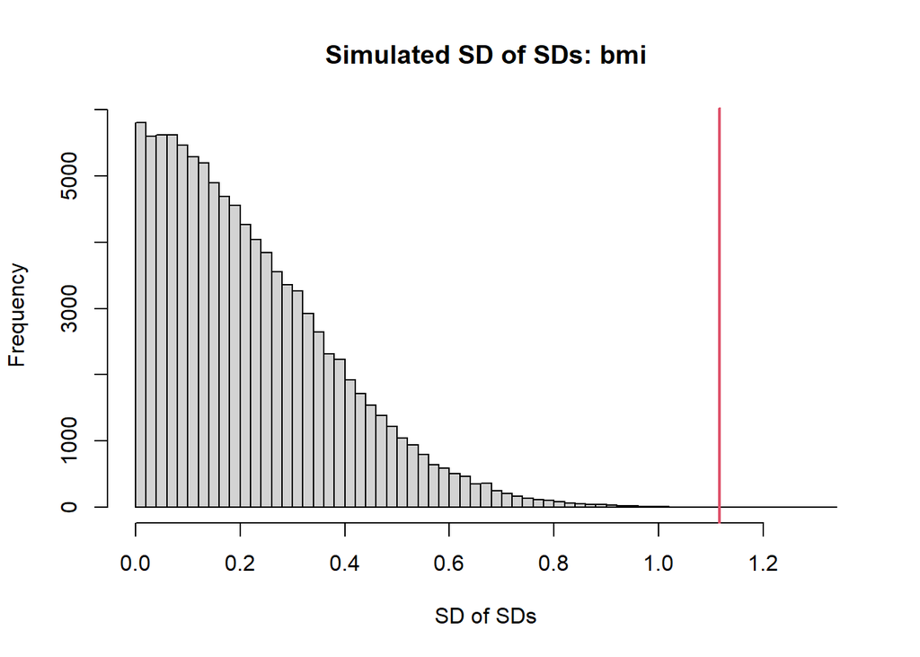

```
##            variable obs_SD_sd p_left p_right p_two
## 1               age     6.763      1       0     0
## 2 avg_glucose_level    12.781      1       0     0
## 3               bmi     1.116      1       0     0
```

**Interpretation:** - The vertical red line represents the observed value from the data  
- The distribution behind it are simulated from the underlying distribution  
- The position of the red line on this distribution tells us how likely it is our observed value would happen by chance.  
- If it is very far to the left this suggests the vast majority of simulations yielded larger variance (i.e. ours is suspiciously small)  
- The p_two column is the two-sided p-value that accompanies this - if the red line is very far to the right or left we expect p <0.05

### Check 42 - Is there an unusually low proportion of missing data?

```
## # A tibble: 16 × 3
##    variable              n_miss pct_miss
##    <chr>                  <int>    <num>
##  1 bmi                      201     3.93
##  2 id                         0     0
##  3 gender                     0     0
##  4 age                        0     0
##  5 hypertension               0     0
##  6 heart_disease              0     0
##  7 ever_married               0     0
##  8 work_type                  0     0
##  9 Residence_type             0     0
## 10 avg_glucose_level          0     0
## 11 smoking_status             0     0
## 12 group                      0     0
## 13 Study.group                0     0
## 14 recruitment_order_var      0     0
## 15 recruitment.order          0     0
## 16 row_number                 0     0
```

### Check 43 - Are there missing or duplicate participant IDs?

```
## === Participant ID Integrity Check ===
```

```
## Total participants in dataset: 5110
```

```
## Total unique IDs: 5110
```

```
## ID range: 67 to 72940
```

```
## Expected IDs in range: 72874
```

```
## ⚠️ MISSING IDs: 67764 ID(s) missing from sequence
##    Missing ID(s): 68, 69, 70, 71, 72, 73, 74, 75, 76, 78, 79, 80, 81, 82, 83, 85, 86, 87, 88, 89 ... (67744 more)
```

```
## ✅ No duplicate IDs - all participant IDs are unique
```

```
## **Overall: ⚠️ ID issues detected - investigate further**
```

**Interpretation:**

**Missing IDs:** - Gaps in ID sequence may indicate withdrawn participants (normal) or selective data inclusion (suspicious) - Large blocks of missing IDs are more concerning than scattered gaps

**Duplicate IDs:** - Any duplicate IDs are a serious data integrity issue - May indicate copy-paste errors, data merging problems, or fabrication - All duplicates should be investigated and resolved

**Context matters:** If it is considered plausible, IDs may be assigned in the pre-recruitment phase and not everyone subsequently makes it into the study, which would also account for gaps.

### Check 44 - Do missing data appear too symmetrical across groups or implausibly few?

```
## # A tibble: 14 × 5
##    variable          Missing_df1 Percent_df1 Missing_df2 Percent_df2
##    <chr>                   <int>       <num>       <int>       <num>
##  1 bmi                       161        3.31          40        16.1
##  2 id                          0        0              0         0
##  3 gender                      0        0              0         0
##  4 age                         0        0              0         0
##  5 hypertension                0        0              0         0
##  6 heart_disease               0        0              0         0
##  7 ever_married                0        0              0         0
##  8 work_type                   0        0              0         0
##  9 Residence_type              0        0              0         0
## 10 avg_glucose_level           0        0              0         0
## 11 smoking_status              0        0              0         0
## 12 group                       0        0              0         0
## 13 Study.group                 0        0              0         0
## 14 row_number                  0        0              0         0
```

### Check 45 - Are the coefficients of variation implausibly similar between variables and between study groups?

Coefficient of Variation Comparison Between Groups

| Variable | Coefficient_of_Variation_Group1 | Coefficient_of_Variation_Group2 |
| --- | --- | --- |
| age | 0.5311 | 0.1879 |
| avg_glucose_level | 0.4184 | 0.4672 |
| bmi | 0.2744 | 0.2077 |

### Check 46 - Is there unexpected variation in the number of decimal places reported within a variable?

```
## **Decimal Place Variation Check:**
```

```
##
##
## |Variable          | Min DP | Max DP | Most Common | N Variants |Assessment       |
## |:-----------------|:------:|:------:|:-----------:|:----------:|:----------------|
## |age               |   0    |   23   |      0      |     5      |⚠️ High variation |
## |avg_glucose_level |   0    |   20   |     20      |     6      |⚠️ High variation |
## |bmi               |   0    |   20   |     20      |     3      |⚠️ Some variation |
##
## ⚠️ **Variables with High Decimal Variation:**
##
## These variables show unusual variation in decimal places, which may indicate:
## - **age**: 0 to 23 decimal places (5 different precisions)
## - **avg_glucose_level**: 0 to 20 decimal places (6 different precisions)
## - **bmi**: 0 to 20 decimal places (3 different precisions)
##
## ---
##
## ## Detailed Breakdown of Variables with High Decimal Variation
##
##
## ### age
##
## **Decimal place distribution:**
##
## decimal_places
##    0   19   21   22   23
## 4995    8   64   41    2
##
## **Examples by decimal places:**
##
##   - **0 decimals**: 67, 61, 80
##   - **19 decimals**: 1.6399999999999999023, 1.6399999999999999023, 1.6399999999999999023
##   - **21 decimals**: 1.320000000000000062172, 1.800000000000000044409, 1.080000000000000071054
##   - **22 decimals**: 0.6400000000000000133227, 0.8800000000000000044409, 0.3200000000000000066613
##   - **23 decimals**: 0.08000000000000000166533, 0.08000000000000000166533
##
##
## ### avg_glucose_level
##
## **Decimal place distribution:**
```

[output cut: 12 more lines]

```
##
##
## ### bmi
##
## **Decimal place distribution:**
##
## decimal_places
##    0    1   20
##  487  509 3913
##
## **Examples by decimal places:**
##
##   - **0 decimals**: 24, 29, 32
##   - **1 decimals**: 32.5, 37.5, 32.5
##   - **20 decimals**: 36.60000000000000142109, 34.39999999999999857891, 27.39999999999999857891
```

**Interpretation:**

**What to look for:**  
- **Uniform decimals (all same):** Expected for most measured variables  
- **1-2 decimal variations:** Normal for data entry or rounding  
- **High variation (3+ different decimal places):** Unusual and may indicate:  
- Mixed measurement instruments  
- Data from multiple sources  
- Fabrication (inconsistent precision)

**Red flags:**  
- ⚠️ Some values with 0 decimals, others with 3-4 decimals (e.g., age: 45, 46.234, 47.1)  
- ⚠️ Inconsistent precision within supposedly measured data  
- ⚠️ More decimal places than measurement instrument supports

**Context matters:**  
- If the trial collected data from multiple centres, this may explain variations in decimal usage - Age in whole years: All 0 decimals is normal  
- Blood pressure: Should be consistent (all 0 or all 1 decimal)  
- Lab values: Usually uniform precision

### Check 47 - Is there evidence of ‘number-bunching’ when analysing the frequency with which values get repeated within a dataset.

```
##
## Variable: age
##   Observed AF: 64.244
##   Permuted AF range: 62.536 to 62.989
##   Observed within range: FALSE
```

```
##
## Variable: avg_glucose_level
##   Observed AF: 1.548
##   Permuted AF range: 1.489 to 1.593
##   Observed within range: TRUE
```

```
##
## Variable: bmi
##   Observed AF: 20.334
##   Permuted AF range: 20.122 to 20.637
##   Observed within range: TRUE
```

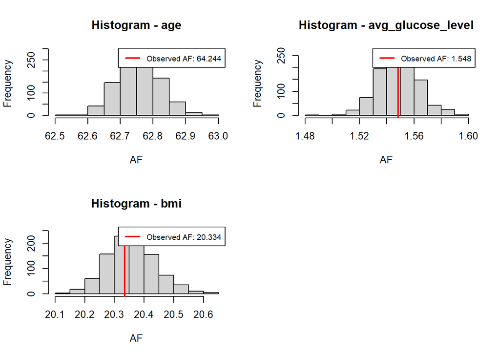

**Interpretation**  
For this test we can only interpret variables for which there is some spread. **If a variable is reported to no decimal places, or to too many decimal places we will get a single grey box and should not be interpreted.** For variables where a histogram has been created, the position of the red line tells us whether our observed average-frequency is more (far to the right) or less (far to the left) than would be expected.  
Note - the red line may be outside the range of the graph but it’s value will be reported for interpretation.

High observed average frequency (AF) (red line far right) may indicate:  
1. CLINICAL: Standard dosing conventions (common for medication doses)  
2. ROUNDING: Values rounded to convenient numbers (5, 10, 30, etc.)  
3. CALCULATION: Derived variables producing integer results  
4. CONCERN: Possible copy-paste or fabrication (check for implausible patterns  
Therefore, For medication doses, bunching at standard dose increments is EXPECTED.  
Focus on whether the specific repeated values make clinical sense.

# Domain 5 - Inspecting internal/external consistency

### Check 49 - Are there unexplained inconsistencies in overall participant numbers and participant numbers per group, e.g. between CONSORT diagram, registration record, publication text/tables, and IPD?

```
## **SCENARIO: No recruitment dates available**
## Testing if ID numbers increase sequentially in the order participants appear in the dataset.
## (Row position may represent data entry order, enrollment sequence, or file organization)
##
## Do ID numbers match dataset row order? NO ⚠️
## 5108 out of 5110 IDs don't match row order (100.0%)
##
## First 10 discrepancies:
```

```
## [[1]]
## [1] 9046
##
## [[2]]
## [1] 51676
##
## [[3]]
## [1] 31112
##
## [[4]]
## [1] 60182
##
## [[5]]
## [1] 1665
##
## [[6]]
## [1] 56669
##
## [[7]]
## [1] 53882
##
## [[8]]
## [1] 10434
##
## [[9]]
## [1] 27419
##
## [[10]]
## [1] 60491
```

### Check 51 - Are data internally inconsistent?

Detected Outliers in Multivariate Space

| id | group | age | avg_glucose_level | bmi |
| --- | --- | --- | --- | --- |
| 13861 | 2 | 52 | 233.29 | 48.9 |
| 54401 | 2 | 80 | 252.72 | 30.5 |
| 17004 | 2 | 70 | 221.58 | 47.5 |
| 41069 | 2 | 45 | 224.10 | 56.6 |
| 13491 | 2 | 80 | 259.63 | 31.7 |
| 71279 | 2 | 71 | 263.32 | 38.7 |
| 69112 | 2 | 68 | 271.74 | 31.1 |
| 58267 | 2 | 70 | 242.52 | 45.5 |
| 28674 | 1 | 74 | 205.84 | 54.6 |
| 72911 | 1 | 57 | 129.54 | 60.9 |
| 66333 | 1 | 52 | 78.40 | 64.8 |
| 1307 | 1 | 61 | 170.05 | 60.2 |
| 545 | 1 | 42 | 210.48 | 71.9 |
| 3590 | 1 | 28 | 80.40 | 57.5 |
| 41097 | 1 | 23 | 70.03 | 78.0 |
| 8332 | 1 | 50 | 206.25 | 53.4 |
| 42550 | 1 | 81 | 246.34 | 21.1 |
| 5821 | 1 | 50 | 217.39 | 50.6 |
| 35913 | 1 | 55 | 206.40 | 54.8 |
| 34496 | 1 | 82 | 253.16 | 47.5 |
| 37759 | 1 | 53 | 72.63 | 66.8 |
| 11412 | 1 | 59 | 234.82 | 51.8 |
| 25405 | 1 | 62 | 187.52 | 57.7 |
| 5355 | 1 | 63 | 231.69 | 56.1 |
| 56420 | 1 | 17 | 61.67 | 97.6 |
| 61895 | 1 | 65 | 220.47 | 48.7 |
| 27626 | 1 | 60 | 266.59 | 25.5 |
| 20292 | 1 | 24 | 85.55 | 63.3 |
| 65895 | 1 | 52 | 98.27 | 61.2 |
| 32604 | 1 | 49 | 215.81 | 58.1 |
| 26267 | 1 | 76 | 267.61 | 27.9 |
| 11111 | 1 | 66 | 205.01 | 52.7 |
| 13155 | 1 | 67 | 263.56 | 26.3 |
| 21661 | 1 | 68 | 228.05 | 51.9 |
| 23047 | 1 | 43 | 100.16 | 59.7 |
| 14872 | 1 | 45 | 239.19 | 52.5 |
| 38575 | 1 | 58 | 209.15 | 52.9 |
| 72784 | 1 | 52 | 118.46 | 61.6 |
| 4077 | 1 | 49 | 219.70 | 53.8 |
| 27660 | 1 | 73 | 198.30 | 54.3 |
| 11192 | 1 | 45 | 218.10 | 55.0 |
| 70670 | 1 | 27 | 57.96 | 64.4 |
| 51856 | 1 | 38 | 56.90 | 92.0 |
| 63915 | 1 | 39 | 87.39 | 57.9 |
| 50070 | 1 | 62 | 261.67 | 43.0 |
| 60675 | 1 | 48 | 221.08 | 57.2 |
| 5131 | 1 | 51 | 107.72 | 60.9 |
| 16245 | 1 | 51 | 211.83 | 56.6 |
| 10995 | 1 | 76 | 267.60 | 30.5 |
| 65405 | 1 | 79 | 253.86 | 28.8 |

**Interpretation**  
This merely presents a list of multivariate outliers. The idea being that this may flag rows of data where one variable may have unusual combinations of values - i.e. very high BMI & very low blood pressure. This requires manual checking for contradictions using knowledge of the variables.

### Check 52 - Does an interaction test to assess the subgroup homogeneity suggest implausible consistency?

```
##
## === SUBGROUP HOMOGENEITY ANALYSIS RESULTS ===
```

```
## === Continuous Outcomes ===
```

```
##
##
## |outcome           |outcome_type |subgroup  |test           | p_interaction| p_under|
## |:-----------------|:------------|:---------|:--------------|-------------:|-------:|
## |avg_glucose_level |continuous   |work_type |LM interaction |         0.001|       1|
```

```
##
## === Binary Outcomes ===
```

```
## No binary outcomes available for analysis.
```

```
##
## === Multicategory Outcomes ===
```

```
## No multicategory outcomes available for analysis.
```

**Interpretation**

NOTE: NA’s are likely a result of sparse data (f any combination of subgroup × group × outcome has zero or very few observations, the tests fail).

Continuous outcomes  
p_interaction small → subgroup effects differ (heterogeneity).  
p_under large (e.g., > 0.95) → under-dispersion (effects too similar across subgroups) → flag as implausibly consistent if that’s your rule.

Binary outcomes  
p_bd (Breslow–Day Tarone) small → heterogeneity of ORs.  
Very large p_bd or large logistic p_lrt for the no-interaction model (i.e., non-sig interaction) → consistent; set a high-p threshold if you want to flag too consistent.

Multi-category outcomes  
p_lrt small → subgroup × treatment interaction present (heterogeneity).  
Very large p_lrt → unusually consistent; again use a high-p threshold if you want to flag.

### Check 53 - Are there concerns relating to the frequency or nature of data errors?

```
## #### Univariate Outliers
```

```
## **Flagged outliers (robust z-score > 3.5):**
```

```
##
##
## |  Row|Variable          |  Value| Robust Z-score|
## |----:|:-----------------|------:|--------------:|
## |    1|avg_glucose_level | 228.69|          5.249|
## |    2|avg_glucose_level | 202.21|          4.233|
## |    6|avg_glucose_level | 186.21|          3.619|
## |   14|avg_glucose_level | 219.84|          4.909|
## |   15|avg_glucose_level | 214.09|          4.689|
## |   17|avg_glucose_level | 191.61|          3.826|
## |   18|avg_glucose_level | 221.29|          4.965|
## |   20|avg_glucose_level | 217.08|          4.803|
## |   21|avg_glucose_level | 193.94|          3.916|
## |   22|avg_glucose_level | 233.29|          5.425|
## |   23|avg_glucose_level | 228.70|          5.249|
## |   24|avg_glucose_level | 208.30|          4.466|
## |   28|avg_glucose_level | 189.84|          3.758|
## |   29|avg_glucose_level | 195.23|          3.965|
## |   30|avg_glucose_level | 211.78|          4.600|
## |   31|avg_glucose_level | 212.08|          4.612|
## |   33|avg_glucose_level | 196.92|          4.030|
## |   34|avg_glucose_level | 252.72|          6.171|
## |   37|avg_glucose_level | 219.72|          4.905|
## |   45|avg_glucose_level | 213.03|          4.648|
## |   46|avg_glucose_level | 243.58|          5.820|
## |   55|avg_glucose_level | 197.54|          4.054|
## |   56|avg_glucose_level | 196.71|          4.022|
## |   58|avg_glucose_level | 237.75|          5.596|
## |   59|avg_glucose_level | 194.99|          3.956|
## |   61|avg_glucose_level | 185.17|          3.579|
## |   67|avg_glucose_level | 221.58|          4.976|
## |   74|avg_glucose_level | 228.56|          5.244|
## |   77|avg_glucose_level | 240.09|          5.686|
## |   91|avg_glucose_level | 226.98|          5.183|
## |   96|avg_glucose_level | 235.63|          5.515|
## |   98|avg_glucose_level | 240.59|          5.705|
## |  102|avg_glucose_level | 190.32|          3.777|
## |  103|avg_glucose_level | 231.61|          5.361|
## |  108|avg_glucose_level | 191.82|          3.834|
## |  114|avg_glucose_level | 224.10|          5.073|
```

[output cut: 574 more lines]

```
## | 3703|bmi               |  54.70|          3.817|
## | 3826|bmi               |  61.60|          4.808|
## | 3910|bmi               |  53.80|          3.688|
## | 3932|bmi               |  54.30|          3.760|
## | 3981|bmi               |  55.00|          3.860|
## | 4155|bmi               |  57.20|          4.176|
## | 4189|bmi               |  64.40|          5.209|
## | 4210|bmi               |  92.00|          9.170|
## | 4226|bmi               |  55.90|          3.990|
## | 4352|bmi               |  57.90|          4.277|
## | 4408|bmi               |  55.70|          3.961|
## | 4476|bmi               |  57.20|          4.176|
## | 4839|bmi               |  60.90|          4.707|
## | 4907|bmi               |  54.10|          3.731|
## | 4953|bmi               |  56.60|          4.090|
```

```
##
## **Summary by variable:**
```

```
##
##
## |Variable          |    N| N Outliers| Proportion Outliers|
## |:-----------------|----:|----------:|-------------------:|
## |age               | 5110|          0|              0.0000|
## |avg_glucose_level | 5110|        567|              0.1110|
## |bmi               | 4909|         58|              0.0118|
```

**Interpretation:**  
These univariate outliers are useful for spotting extreme values that may represent data entry errors, unit errors, or typos that might not be obvious from Excel scrutiny alone. Review flagged values to determine if they are genuine extreme observations or data errors. **Interpretation:**  
These univariate outliers are useful for spotting extreme values that may represent data entry errors, unit errors, or typos that might not be obvious from Excel scrutiny alone. Review flagged values to determine if they are genuine extreme observations or data errors.

### Check 58 - Are there repeating data patterns across rare variables?

**Variables with rare categories (<10%):**

gender, hypertension, heart_disease, work_type

#### Dataset sorted by: gender

First 50 rows sorted by gender

|  | gender | hypertension | heart_disease | ever_married | work_type | Residence_type | smoking_status | age | avg_glucose_level | bmi |
| --- | --- | --- | --- | --- | --- | --- | --- | --- | --- | --- |
| 3117 | Other | 0 | 0 | No | Private | Rural | formerly smoked | 26 | 143.33 | 22.4 |
| 1 | Male | 0 | 1 | Yes | Private | Urban | formerly smoked | 67 | 228.69 | 36.6 |
| 3 | Male | 0 | 1 | Yes | Private | Rural | never smoked | 80 | 105.92 | 32.5 |
| 6 | Male | 0 | 0 | Yes | Private | Urban | formerly smoked | 81 | 186.21 | 29.0 |
| 7 | Male | 1 | 1 | Yes | Private | Rural | never smoked | 74 | 70.09 | 27.4 |
| 14 | Male | 0 | 1 | Yes | Private | Urban | Unknown | 78 | 219.84 | NA |
| 17 | Male | 0 | 1 | Yes | Private | Urban | smokes | 64 | 191.61 | 37.5 |
| 18 | Male | 1 | 0 | Yes | Private | Urban | smokes | 75 | 221.29 | 25.8 |
| 20 | Male | 0 | 1 | No | Govt_job | Urban | Unknown | 57 | 217.08 | NA |
| 24 | Male | 0 | 1 | Yes | Private | Rural | Unknown | 82 | 208.30 | 32.5 |
| 25 | Male | 0 | 0 | Yes | Private | Urban | formerly smoked | 71 | 102.87 | 27.2 |
| 26 | Male | 0 | 0 | Yes | Self-employed | Rural | never smoked | 80 | 104.12 | 23.5 |
| 28 | Male | 0 | 0 | Yes | Private | Rural | Unknown | 58 | 189.84 | NA |
| 29 | Male | 0 | 1 | Yes | Self-employed | Urban | smokes | 69 | 195.23 | 28.3 |
| 30 | Male | 0 | 0 | Yes | Private | Rural | formerly smoked | 59 | 211.78 | NA |
| 31 | Male | 1 | 0 | Yes | Private | Urban | smokes | 57 | 212.08 | 44.2 |
| 32 | Male | 0 | 0 | Yes | Private | Rural | Unknown | 42 | 83.41 | 25.4 |
| 34 | Male | 0 | 1 | Yes | Self-employed | Urban | formerly smoked | 80 | 252.72 | 30.5 |
| 35 | Male | 0 | 0 | No | Govt_job | Urban | never smoked | 48 | 84.20 | 29.7 |
| 37 | Male | 0 | 0 | Yes | Private | Rural | formerly smoked | 74 | 219.72 | 33.7 |
| 39 | Male | 0 | 0 | No | Private | Rural | Unknown | 58 | 92.62 | 32.0 |
| 41 | Male | 0 | 0 | Yes | Private | Rural | formerly smoked | 78 | 78.03 | 23.9 |
| 42 | Male | 0 | 0 | Yes | Private | Urban | never smoked | 54 | 71.22 | 28.5 |
| 43 | Male | 0 | 1 | Yes | Private | Urban | smokes | 82 | 144.90 | 26.4 |
| 45 | Male | 1 | 0 | Yes | Govt_job | Urban | smokes | 60 | 213.03 | 20.2 |
| 46 | Male | 1 | 0 | Yes | Private | Rural | never smoked | 76 | 243.58 | 33.6 |
| 49 | Male | 0 | 0 | Yes | Self-employed | Urban | never smoked | 81 | 99.33 | 33.7 |
| 52 | Male | 1 | 0 | Yes | Private | Urban | formerly smoked | 78 | 75.32 | NA |
| 56 | Male | 0 | 1 | Yes | Private | Rural | formerly smoked | 63 | 196.71 | 36.5 |
| 58 | Male | 0 | 0 | Yes | Private | Urban | formerly smoked | 78 | 237.75 | NA |
| 59 | Male | 1 | 0 | Yes | Self-employed | Urban | never smoked | 73 | 194.99 | 32.8 |
| 65 | Male | 0 | 0 | Yes | Private | Urban | Unknown | 75 | 104.72 | NA |
| 66 | Male | 1 | 0 | No | Private | Urban | never smoked | 78 | 113.01 | 24.0 |
| 68 | Male | 0 | 0 | Yes | Private | Urban | Unknown | 76 | 104.47 | 20.3 |
| 69 | Male | 0 | 0 | Yes | Private | Urban | formerly smoked | 59 | 86.23 | 30.0 |
| 74 | Male | 0 | 0 | Yes | Private | Rural | never smoked | 63 | 228.56 | 27.4 |
| 77 | Male | 1 | 0 | Yes | Private | Urban | never smoked | 80 | 240.09 | 27.0 |
| 80 | Male | 0 | 0 | Yes | Self-employed | Urban | Unknown | 43 | 143.43 | 45.9 |
| 81 | Male | 0 | 0 | Yes | Private | Rural | Unknown | 59 | 96.16 | 44.1 |
| 85 | Male | 0 | 0 | Yes | Private | Urban | Unknown | 58 | 71.20 | NA |
| 86 | Male | 0 | 0 | Yes | Private | Rural | smokes | 54 | 96.97 | 29.1 |
| 87 | Male | 0 | 1 | Yes | Private | Rural | smokes | 61 | 111.81 | 27.3 |
| 89 | Male | 0 | 0 | Yes | Private | Urban | formerly smoked | 47 | 86.94 | 41.1 |
| 90 | Male | 0 | 0 | Yes | Private | Urban | Unknown | 74 | 98.55 | 25.6 |
| 92 | Male | 0 | 0 | Yes | Private | Urban | never smoked | 81 | 72.81 | 26.3 |
| 95 | Male | 0 | 0 | Yes | Private | Rural | never smoked | 45 | 64.14 | 29.4 |
| 98 | Male | 0 | 1 | Yes | Private | Rural | smokes | 58 | 240.59 | 31.4 |
| 99 | Male | 1 | 0 | Yes | Govt_job | Urban | formerly smoked | 57 | 78.92 | 27.7 |
| 101 | Male | 0 | 1 | Yes | Govt_job | Urban | Unknown | 64 | 74.10 | 28.8 |
| 106 | Male | 0 | 0 | Yes | Private | Urban | smokes | 58 | 82.30 | NA |

#### Dataset sorted by: hypertension

First 50 rows sorted by hypertension

|  | gender | hypertension | heart_disease | ever_married | work_type | Residence_type | smoking_status | age | avg_glucose_level | bmi |
| --- | --- | --- | --- | --- | --- | --- | --- | --- | --- | --- |
| 5 | Female | 1 | 0 | Yes | Self-employed | Rural | never smoked | 79 | 174.12 | 24.0 |
| 7 | Male | 1 | 1 | Yes | Private | Rural | never smoked | 74 | 70.09 | 27.4 |
| 11 | Female | 1 | 0 | Yes | Private | Rural | never smoked | 81 | 80.43 | 29.7 |
| 16 | Female | 1 | 0 | Yes | Self-employed | Rural | never smoked | 50 | 167.41 | 30.9 |
| 18 | Male | 1 | 0 | Yes | Private | Urban | smokes | 75 | 221.29 | 25.8 |
| 22 | Female | 1 | 0 | Yes | Self-employed | Urban | never smoked | 52 | 233.29 | 48.9 |
| 31 | Male | 1 | 0 | Yes | Private | Urban | smokes | 57 | 212.08 | 44.2 |
| 33 | Female | 1 | 0 | Yes | Self-employed | Urban | never smoked | 82 | 196.92 | 22.2 |
| 36 | Female | 1 | 1 | No | Private | Rural | formerly smoked | 82 | 84.03 | 26.5 |
| 38 | Female | 1 | 0 | Yes | Private | Rural | formerly smoked | 72 | 74.63 | 23.1 |
| 45 | Male | 1 | 0 | Yes | Govt_job | Urban | smokes | 60 | 213.03 | 20.2 |
| 46 | Male | 1 | 0 | Yes | Private | Rural | never smoked | 76 | 243.58 | 33.6 |
| 50 | Female | 1 | 0 | Yes | Private | Rural | smokes | 39 | 58.09 | 39.2 |
| 52 | Male | 1 | 0 | Yes | Private | Urban | formerly smoked | 78 | 75.32 | NA |
| 54 | Female | 1 | 0 | Yes | Self-employed | Urban | never smoked | 77 | 124.13 | 31.4 |
| 59 | Male | 1 | 0 | Yes | Self-employed | Urban | never smoked | 73 | 194.99 | 32.8 |
| 60 | Female | 1 | 0 | Yes | Govt_job | Urban | never smoked | 54 | 180.93 | 27.7 |
| 62 | Female | 1 | 0 | Yes | Private | Rural | never smoked | 80 | 74.90 | 22.2 |
| 63 | Female | 1 | 0 | Yes | Self-employed | Rural | smokes | 67 | 61.94 | 25.3 |
| 66 | Male | 1 | 0 | No | Private | Urban | never smoked | 78 | 113.01 | 24.0 |
| 70 | Female | 1 | 0 | Yes | Self-employed | Rural | never smoked | 80 | 72.67 | 28.9 |
| 72 | Female | 1 | 0 | Yes | Private | Rural | formerly smoked | 67 | 179.12 | 28.1 |
| 73 | Female | 1 | 0 | Yes | Govt_job | Rural | formerly smoked | 66 | 116.55 | 31.1 |
| 77 | Male | 1 | 0 | Yes | Private | Urban | never smoked | 80 | 240.09 | 27.0 |
| 84 | Female | 1 | 0 | No | Self-employed | Urban | never smoked | 68 | 79.79 | 29.7 |
| 94 | Female | 1 | 0 | Yes | Self-employed | Urban | Unknown | 80 | 68.56 | 26.2 |
| 99 | Male | 1 | 0 | Yes | Govt_job | Urban | formerly smoked | 57 | 78.92 | 27.7 |
| 107 | Female | 1 | 0 | Yes | Private | Rural | formerly smoked | 50 | 73.18 | 30.3 |
| 116 | Male | 1 | 1 | No | Govt_job | Rural | never smoked | 71 | 216.94 | 30.9 |
| 117 | Male | 1 | 0 | Yes | Self-employed | Rural | smokes | 61 | 76.11 | 27.3 |
| 122 | Female | 1 | 0 | Yes | Private | Urban | Unknown | 53 | 62.55 | 30.3 |
| 124 | Male | 1 | 0 | Yes | Private | Rural | never smoked | 56 | 249.31 | 35.8 |
| 127 | Male | 1 | 0 | Yes | Self-employed | Urban | formerly smoked | 78 | 93.13 | NA |
| 131 | Female | 1 | 0 | Yes | Private | Rural | never smoked | 73 | 190.14 | 36.5 |
| 132 | Female | 1 | 0 | No | Private | Urban | never smoked | 78 | 130.54 | 20.1 |
| 133 | Male | 1 | 0 | No | Private | Rural | never smoked | 69 | 182.99 | 36.5 |
| 135 | Female | 1 | 0 | Yes | Self-employed | Rural | never smoked | 68 | 206.09 | 26.7 |
| 139 | Male | 1 | 0 | Yes | Self-employed | Rural | formerly smoked | 76 | 194.37 | 27.0 |
| 143 | Female | 1 | 0 | Yes | Private | Urban | never smoked | 74 | 70.28 | 21.8 |
| 144 | Female | 1 | 1 | No | Self-employed | Urban | never smoked | 69 | 72.17 | 36.8 |
| 145 | Female | 1 | 0 | Yes | Private | Urban | never smoked | 72 | 221.79 | 30.0 |
| 149 | Female | 1 | 0 | Yes | Govt_job | Rural | never smoked | 57 | 67.41 | 32.9 |
| 160 | Female | 1 | 0 | Yes | Self-employed | Rural | never smoked | 81 | 74.02 | 25.0 |
| 164 | Female | 1 | 0 | No | Private | Urban | never smoked | 78 | 203.87 | 45.7 |
| 165 | Female | 1 | 0 | Yes | Self-employed | Urban | formerly smoked | 70 | 89.13 | 34.2 |
| 168 | Male | 1 | 0 | Yes | Private | Rural | never smoked | 79 | 75.02 | NA |
| 169 | Female | 1 | 0 | No | Govt_job | Urban | formerly smoked | 79 | 98.02 | 22.3 |
| 172 | Female | 1 | 1 | No | Self-employed | Rural | never smoked | 79 | 60.94 | NA |
| 174 | Female | 1 | 0 | Yes | Self-employed | Rural | formerly smoked | 80 | 91.02 | 32.9 |
| 176 | Male | 1 | 0 | Yes | Self-employed | Rural | never smoked | 72 | 185.49 | 37.1 |

#### Dataset sorted by: heart_disease

First 50 rows sorted by heart_disease

|  | gender | hypertension | heart_disease | ever_married | work_type | Residence_type | smoking_status | age | avg_glucose_level | bmi |
| --- | --- | --- | --- | --- | --- | --- | --- | --- | --- | --- |
| 1 | Male | 0 | 1 | Yes | Private | Urban | formerly smoked | 67 | 228.69 | 36.6 |
| 3 | Male | 0 | 1 | Yes | Private | Rural | never smoked | 80 | 105.92 | 32.5 |
| 7 | Male | 1 | 1 | Yes | Private | Rural | never smoked | 74 | 70.09 | 27.4 |
| 12 | Female | 0 | 1 | Yes | Govt_job | Rural | smokes | 61 | 120.46 | 36.8 |
| 14 | Male | 0 | 1 | Yes | Private | Urban | Unknown | 78 | 219.84 | NA |
| 15 | Female | 0 | 1 | Yes | Private | Urban | never smoked | 79 | 214.09 | 28.2 |
| 17 | Male | 0 | 1 | Yes | Private | Urban | smokes | 64 | 191.61 | 37.5 |
| 20 | Male | 0 | 1 | No | Govt_job | Urban | Unknown | 57 | 217.08 | NA |
| 24 | Male | 0 | 1 | Yes | Private | Rural | Unknown | 82 | 208.30 | 32.5 |
| 29 | Male | 0 | 1 | Yes | Self-employed | Urban | smokes | 69 | 195.23 | 28.3 |
| 34 | Male | 0 | 1 | Yes | Self-employed | Urban | formerly smoked | 80 | 252.72 | 30.5 |
| 36 | Female | 1 | 1 | No | Private | Rural | formerly smoked | 82 | 84.03 | 26.5 |
| 43 | Male | 0 | 1 | Yes | Private | Urban | smokes | 82 | 144.90 | 26.4 |
| 47 | Female | 0 | 1 | No | Self-employed | Urban | Unknown | 75 | 109.78 | NA |
| 53 | Female | 0 | 1 | Yes | Private | Rural | never smoked | 79 | 127.29 | 27.7 |
| 56 | Male | 0 | 1 | Yes | Private | Rural | formerly smoked | 63 | 196.71 | 36.5 |
| 76 | Female | 0 | 1 | Yes | Self-employed | Rural | formerly smoked | 80 | 66.72 | 21.7 |
| 87 | Male | 0 | 1 | Yes | Private | Rural | smokes | 61 | 111.81 | 27.3 |
| 88 | Female | 0 | 1 | Yes | Private | Rural | formerly smoked | 70 | 59.35 | 32.3 |
| 91 | Female | 0 | 1 | Yes | Private | Urban | never smoked | 79 | 226.98 | 29.8 |
| 98 | Male | 0 | 1 | Yes | Private | Rural | smokes | 58 | 240.59 | 31.4 |
| 101 | Male | 0 | 1 | Yes | Govt_job | Urban | Unknown | 64 | 74.10 | 28.8 |
| 104 | Female | 0 | 1 | Yes | Self-employed | Rural | Unknown | 81 | 78.70 | 19.4 |
| 111 | Male | 0 | 1 | Yes | Private | Rural | formerly smoked | 79 | 129.98 | 22.6 |
| 112 | Male | 0 | 1 | Yes | Private | Urban | smokes | 80 | 68.53 | 24.2 |
| 116 | Male | 1 | 1 | No | Govt_job | Rural | never smoked | 71 | 216.94 | 30.9 |
| 141 | Male | 0 | 1 | Yes | Govt_job | Rural | never smoked | 82 | 103.68 | 25.0 |
| 144 | Female | 1 | 1 | No | Self-employed | Urban | never smoked | 69 | 72.17 | 36.8 |
| 150 | Female | 0 | 1 | Yes | Private | Rural | never smoked | 70 | 239.07 | 26.1 |
| 152 | Male | 0 | 1 | Yes | Private | Urban | formerly smoked | 68 | 223.83 | 31.9 |
| 156 | Female | 0 | 1 | Yes | Private | Rural | never smoked | 77 | 231.56 | 36.9 |
| 162 | Male | 0 | 1 | Yes | Private | Urban | smokes | 71 | 81.76 | NA |
| 172 | Female | 1 | 1 | No | Self-employed | Rural | never smoked | 79 | 60.94 | NA |
| 185 | Male | 1 | 1 | Yes | Private | Urban | smokes | 61 | 112.24 | 37.4 |
| 187 | Male | 0 | 1 | Yes | Self-employed | Urban | formerly smoked | 63 | 116.69 | 34.5 |
| 188 | Female | 1 | 1 | Yes | Govt_job | Urban | formerly smoked | 82 | 215.94 | 27.9 |
| 190 | Male | 0 | 1 | Yes | Private | Urban | Unknown | 61 | 209.86 | NA |
| 194 | Male | 1 | 1 | Yes | Private | Rural | smokes | 68 | 271.74 | 31.1 |
| 202 | Male | 1 | 1 | Yes | Private | Urban | formerly smoked | 80 | 175.29 | 31.5 |
| 216 | Female | 0 | 1 | No | Private | Urban | smokes | 79 | 205.33 | 31.0 |
| 218 | Female | 1 | 1 | Yes | Private | Urban | smokes | 55 | 210.40 | 40.0 |
| 219 | Female | 1 | 1 | Yes | Self-employed | Urban | smokes | 76 | 199.86 | NA |
| 220 | Male | 0 | 1 | Yes | Govt_job | Rural | never smoked | 73 | 219.73 | 28.6 |
| 221 | Male | 1 | 1 | Yes | Private | Urban | smokes | 81 | 250.89 | 28.1 |
| 226 | Female | 0 | 1 | Yes | Private | Urban | Unknown | 57 | 216.58 | 31.0 |
| 240 | Male | 0 | 1 | Yes | Private | Urban | smokes | 60 | 91.92 | 35.9 |
| 244 | Female | 1 | 1 | Yes | Private | Urban | formerly smoked | 68 | 247.51 | 40.5 |
| 257 | Female | 0 | 1 | Yes | Self-employed | Rural | never smoked | 75 | 243.53 | 27.0 |
| 261 | Male | 0 | 1 | Yes | Private | Urban | formerly smoked | 79 | 57.08 | 22.0 |
| 269 | Female | 0 | 1 | Yes | Self-employed | Urban | smokes | 79 | 67.84 | 25.2 |

#### Dataset sorted by: work_type

First 50 rows sorted by work_type

|  | gender | hypertension | heart_disease | ever_married | work_type | Residence_type | smoking_status | age | avg_glucose_level | bmi |
| --- | --- | --- | --- | --- | --- | --- | --- | --- | --- | --- |
| 254 | Male | 0 | 0 | No | Never_worked | Rural | Unknown | 14 | 161.28 | 19.1 |
| 604 | Male | 0 | 0 | No | Never_worked | Urban | never smoked | 23 | 125.26 | 18.7 |
| 887 | Female | 0 | 0 | No | Never_worked | Urban | never smoked | 19 | 86.96 | 25.8 |
| 940 | Male | 0 | 0 | No | Never_worked | Rural | Unknown | 13 | 111.48 | 20.8 |
| 960 | Male | 0 | 0 | No | Never_worked | Urban | never smoked | 17 | 113.25 | 23.4 |
| 1463 | Male | 0 | 0 | No | Never_worked | Rural | Unknown | 17 | 61.01 | 32.5 |
| 1790 | Female | 0 | 0 | No | Never_worked | Urban | never smoked | 13 | 70.93 | 22.9 |
| 1923 | Male | 0 | 0 | No | Never_worked | Urban | never smoked | 16 | 59.99 | 28.2 |
| 2347 | Female | 0 | 0 | No | Never_worked | Urban | never smoked | 14 | 148.37 | 22.7 |
| 2722 | Female | 0 | 0 | No | Never_worked | Rural | never smoked | 17 | 88.57 | 31.1 |
| 2741 | Male | 0 | 0 | No | Never_worked | Rural | Unknown | 15 | 79.59 | 28.4 |
| 2782 | Female | 0 | 0 | No | Never_worked | Urban | never smoked | 16 | 84.40 | 25.9 |
| 2918 | Female | 0 | 0 | No | Never_worked | Urban | Unknown | 18 | 82.36 | 22.7 |
| 3197 | Male | 0 | 0 | No | Never_worked | Urban | never smoked | 14 | 137.91 | 41.8 |
| 3469 | Male | 0 | 0 | No | Never_worked | Rural | never smoked | 17 | 124.38 | 31.2 |
| 3973 | Male | 0 | 0 | No | Never_worked | Urban | Unknown | 15 | 64.29 | 16.7 |
| 4069 | Female | 0 | 0 | No | Never_worked | Urban | never smoked | 16 | 102.10 | 27.1 |
| 4161 | Female | 0 | 0 | No | Never_worked | Urban | never smoked | 18 | 81.73 | 21.6 |
| 4411 | Male | 0 | 0 | No | Never_worked | Urban | Unknown | 13 | 85.08 | 14.6 |
| 4612 | Female | 0 | 0 | No | Never_worked | Urban | never smoked | 17 | 78.08 | 44.9 |
| 4773 | Female | 0 | 0 | No | Never_worked | Urban | Unknown | 18 | 97.65 | 21.5 |
| 4786 | Female | 0 | 0 | No | Never_worked | Rural | never smoked | 16 | 68.27 | 20.4 |
| 12 | Female | 0 | 1 | Yes | Govt_job | Rural | smokes | 61 | 120.46 | 36.8 |
| 20 | Male | 0 | 1 | No | Govt_job | Urban | Unknown | 57 | 217.08 | NA |
| 21 | Female | 0 | 0 | Yes | Govt_job | Rural | smokes | 71 | 193.94 | 22.4 |
| 35 | Male | 0 | 0 | No | Govt_job | Urban | never smoked | 48 | 84.20 | 29.7 |
| 45 | Male | 1 | 0 | Yes | Govt_job | Urban | smokes | 60 | 213.03 | 20.2 |
| 55 | Female | 0 | 0 | Yes | Govt_job | Urban | never smoked | 63 | 197.54 | NA |
| 60 | Female | 1 | 0 | Yes | Govt_job | Urban | never smoked | 54 | 180.93 | 27.7 |
| 71 | Female | 0 | 0 | Yes | Govt_job | Rural | formerly smoked | 76 | 62.57 | NA |
| 73 | Female | 1 | 0 | Yes | Govt_job | Rural | formerly smoked | 66 | 116.55 | 31.1 |
| 99 | Male | 1 | 0 | Yes | Govt_job | Urban | formerly smoked | 57 | 78.92 | 27.7 |
| 100 | Female | 0 | 0 | Yes | Govt_job | Urban | never smoked | 69 | 82.81 | 28.0 |
| 101 | Male | 0 | 1 | Yes | Govt_job | Urban | Unknown | 64 | 74.10 | 28.8 |
| 102 | Female | 0 | 0 | Yes | Govt_job | Rural | never smoked | 77 | 190.32 | 31.4 |
| 105 | Female | 0 | 0 | Yes | Govt_job | Urban | Unknown | 57 | 110.52 | 28.5 |
| 110 | Female | 0 | 0 | Yes | Govt_job | Urban | never smoked | 53 | 64.17 | 41.5 |
| 115 | Female | 0 | 0 | No | Govt_job | Urban | Unknown | 68 | 82.10 | 27.1 |
| 116 | Male | 1 | 1 | No | Govt_job | Rural | never smoked | 71 | 216.94 | 30.9 |
| 126 | Female | 0 | 0 | Yes | Govt_job | Urban | never smoked | 72 | 131.41 | 28.4 |
| 129 | Male | 0 | 0 | Yes | Govt_job | Urban | formerly smoked | 82 | 200.59 | 29.0 |
| 130 | Female | 0 | 0 | Yes | Govt_job | Urban | Unknown | 75 | 62.48 | NA |
| 136 | Female | 0 | 0 | Yes | Govt_job | Urban | never smoked | 71 | 263.32 | 38.7 |
| 141 | Male | 0 | 1 | Yes | Govt_job | Rural | never smoked | 82 | 103.68 | 25.0 |
| 149 | Female | 1 | 0 | Yes | Govt_job | Rural | never smoked | 57 | 67.41 | 32.9 |
| 167 | Female | 0 | 0 | Yes | Govt_job | Rural | Unknown | 56 | 162.23 | 27.3 |
| 169 | Female | 1 | 0 | No | Govt_job | Urban | formerly smoked | 79 | 98.02 | 22.3 |
| 179 | Female | 0 | 0 | Yes | Govt_job | Urban | Unknown | 80 | 110.66 | NA |
| 188 | Female | 1 | 1 | Yes | Govt_job | Urban | formerly smoked | 82 | 215.94 | 27.9 |
| 205 | Male | 0 | 0 | Yes | Govt_job | Rural | smokes | 54 | 87.85 | 31.1 |

### Check 59 - Does removal of outliers meaningfully alter the effects of interest?

**Effect of Outlier Removal on Group Comparisons (Continuous Outcomes):**

| Variable | N Out | t-test (Full) | t-test (Clean) | MW (Full) | MW (Clean) |
| --- | --- | --- | --- | --- | --- |
| avg_glucose_level | 627 | 0 | 0.8308 | 0 | 0.8473 |

**Meaningful Changes (p-value crosses 0.05 threshold):**

- **avg_glucose_level**: t-test 0.0000 → 0.8308; MW 0.0000 → 0.8473

⚠️ These variables show meaningful sensitivity to outliers

**Interpretation:**

**What this checks:**  
Whether removing statistical outliers (values >1.5×IQR from quartiles) meaningfully changes group comparison results.

**Key columns:** - **Outliers Removed:** Number of observations excluded  
- **t-test columns:** Parametric test comparing group means  
- **Mann-Whitney columns:** Non-parametric test comparing group distributions  
- Compare Full vs No Outliers for each test

**What to look for:**

✅ **Robust results (good):** - P-values stay above or below 0.05 threshold in both analyses - Small changes in p-value magnitude - Conclusions remain consistent

⚠️ **Fragile results (concerning):** - Significance flips (p < 0.05 becomes p > 0.05, or vice versa)  
- Large changes in p-values (e.g., 0.001 → 0.08)  
- Results highly dependent on a few observations

**Red flags for fabrication:** - Results depend heavily on outliers (may indicate added noise to hide fabrication)  
- Multiple variables show threshold-crossing changes  
- Outliers are driving all significant findings

**Important context:** - Some sensitivity is normal, especially with small samples  
- Clinical significance matters more than statistical significance  
- Consider whether outliers are legitimate extreme values or data errors

# Domain 6 – Inspecting timings in the dataset

### Check 60 - Do visit dates align with contextual expectations (plausibility of visits on Sundays)? Are visit dates uniformly distributed across possible dates across groups?

```
## ⚠️ No visit date variables defined (visit_date_vars is empty or doesn't exist)
## Skipping weekday distribution analysis.
```

### Check 61 - Does inspecting recruitment over calendar time between groups highlight unlikely differences?

```
## ⚠️ recruitment_date_var not defined
## Skipping recruitment date scatter plots.
```

```
## ⚠️ grouping_var not defined
## Skipping cumulative incidence plot.
```

## This check uses a function taken from Hunter et als Individual Participant Data Integrity Tool (Hunter KE, Aberoumand M, Libesman S, Sotiropoulos JX, Williams JG, Aagerup J, Wang R, Mol BW, Li W, Barba A, Shrestha N, Webster AC, Seidler AL. The Individual Participant Data Integrity Tool for assessing the integrity of randomised trials. Res Synth Methods. 2024 Nov;15(6):917-939. doi: 10.1002/jrsm.1738. Epub 2024 Aug 13. PMID: 39136348.)

### Check 62 - Does inspecting time between participant visits reveal irregular or unexplained intervals?

```
## No visit_date variables found in dataset. Skipping visit timeline analysis.
```

```
## No visit date data available for group comparison.
```

### Check 63 - Are differences between actual visit date and target visit date unexpectedly small or large?

```
## Insufficient visit date columns found. Need at least 2 visit dates.
```

**Interpretation** Without an accompanying paper, this is only interpretable if the variables have names which suggest their target length. For example if a variable is called ‘FollowUpDate6Weeks’ you can determine if it did take place at 6 weeks.

# Domain 7 – Inspecting the baseline data

### Check 65 - Are baseline characteristics balanced between groups?

**Method:** Three complementary approaches to test randomization integrity

```
## Analyzing 2 baseline variables (1 continuous, 1 categorical)
##
## === APPROACH 1: Univariate Method (Parametric t-test) ===
##
## Number of baseline variables tested: 2
## Decile Chi-square uniformity test p-value: NA
##
## Insufficient variables or data to perform test.
##
##
## === APPROACH 2: Univariate Method (Non-parametric Mann-Whitney U) ===
##
## Number of baseline variables tested: 2
## Decile Chi-square uniformity test p-value: NA
##
## Insufficient variables or data to perform test.
##
##
## === APPROACH 3: Multivariate Method (Hotelling's T²) ===
##
## Hotelling's T² p-value: NA
##
## Unable to compute Hotelling's T² test.
##
##
## === SUMMARY: Study-Level P-Values ===
##
##
##
## Table: Study-Level Tests of Baseline Balance
##
## |Approach   |Method                        |Test                         | P_value| Interpretation |
## |:----------|:-----------------------------|:----------------------------|-------:|:--------------:|
## |Approach 1 |Univariate (t-test)           |Decile Chi-square uniformity |      NA|       —        |
## |Approach 2 |Univariate (Mann-Whitney U)   |Decile Chi-square uniformity |      NA|       —        |
## |Approach 3 |Multivariate (Hotelling's T²) |Hotelling's T²               |      NA|       —        |
##
##
## --- Individual Variable Tests (Approach 1: t-test) ---
##
##
## |variable  |var_type    |test   |p_value                                                                                              |
## |:---------|:-----------|:------|:----------------------------------------------------------------------------------------------------|
## |age       |continuous  |t-test |0.00000000000000000000000000000000000000000000000000000000000000000000000000000000000000000000002116 |
## |work_type |categorical |fisher |0.00049975012493753121801953742675550529384054243564605712890625000000000000000000000000000000000000 |
##
## --- Individual Variable Tests (Approach 2: Mann-Whitney U) ---
##
##
## |variable  |var_type    |test         |p_value                                                                      |
## |:---------|:-----------|:------------|:----------------------------------------------------------------------------|
## |age       |continuous  |mann-whitney |0.00000000000000000000000000000000000000000000000000000000000000000000003727 |
## |work_type |categorical |fisher       |0.00049975012493753121801953742675550529384054243564605712890625000000000000 |
```

**Interpretation:**

**Three complementary approaches to assess baseline balance:**

**APPROACH 1: Univariate Parametric Method**  
- Tests each continuous variable with **t-test** (assumes normality)  
- Tests each categorical variable with **chi-square or Fisher’s exact**  
- Combines all p-values and tests for **uniform distribution** across deciles  
- **Interpretation of uniformity test:**  
- p < 0.05 → Non-uniform p-values → ⚠️ Evidence against random allocation  
- p ≥ 0.05 → Uniform p-values → ✅ Consistent with randomization

**APPROACH 2: Univariate Non-parametric Method**  
- Tests each continuous variable with **Mann-Whitney U** (no normality assumption)  
- Tests each categorical variable with **chi-square or Fisher’s exact** (same as Approach 1)  
- Combines all p-values and tests for **uniform distribution** across deciles  
- **Interpretation:** Same as Approach 1  
- **Rationale:** Provides robustness check when data are non-normal

**APPROACH 3: Multivariate Method**  
- Tests all continuous variables **simultaneously** using **Hotelling’s T²**  
- Accounts for correlations between baseline variables  
- **Interpretation:**  
- p < 0.05 → Multivariate difference between groups → ⚠️ Baseline imbalance  
- p ≥ 0.05 → No multivariate difference → ✅ Groups balanced

**Overall Assessment:**  
- **Agreement across approaches** strengthens confidence in findings  
- **Disagreement** may indicate:  
- Violations of parametric assumptions (compare Approach 1 vs 2)  
- Univariate balance but multivariate imbalance (or vice versa)  
- Need for careful examination of individual variables

**Red Flags:**  
- ⚠️ Non-uniform p-value distribution in Approaches 1 or 2  
- ⚠️ Significant Hotelling’s T² in Approach 3  
- ⚠️ Inconsistent results across approaches without clear explanation

### Check 66 - Are only a small number of baseline characteristics collected in IPD?

The dataset contains **2** baseline variables.

### Check 67 - Do statistical tests reveal a difference in variances of baseline variables between groups? (Levene, Brown-Forsythe)

```
##
##
## Table: Levene's Test P-Values
##
## |Variable | P_Value|
## |:--------|-------:|
## |age      |       0|
```

**Interpretation**  
These p-values are from Levenes test. A significant p-value suggests variances differ between groups.

### Check 68 - Is there a difference in kurtosis of baseline variables between groups?

**Method:** G₂ kurtosis estimator (unbiased cumulants) with Efron’s Percentile Bootstrap (5000 replicates)

```
## Comparing Group 2 (n=249) vs Group 1 (n=4861)
##
##
##
## Table: Kurtosis Comparison Between Groups (Efron's Percentile Bootstrap via boot.ci, 5000 replicates)
##
## |Variable | n (2)| G₂ (2)| n (1)| G₂ (1)| Difference| 95% CI Lower| 95% CI Upper| p-value|   |
## |:--------|-----:|------:|-----:|------:|----------:|------------:|------------:|-------:|:-:|
## |age      |   249|  3.101|  4861| -0.975|      4.077|       -0.167|        0.227|  0.0000| ⚠️ |
##
## **Summary:**
## - Variables analyzed: 1
## - Significant differences (p < 0.05): 1 (100.0%)
##
## **Variables with significant kurtosis differences:**
## - age: Δ = 4.077, p = 0.0000
```

**Interpretation:**

**What is G₂ kurtosis?** - G₂ is the unbiased kurtosis estimator based on cumulants - Recommended by Jerome & Kibria (2018) for best coverage probability - Excess kurtosis: 0 = normal-like tails, positive = heavier tails, negative = lighter tails

**What does Efron’s Percentile Bootstrap do?** - Resamples from combined data 5,000 times - Calculates kurtosis difference for each resample - 95% CI = 2.5th to 97.5th percentile of bootstrap distribution (calculated via boot.ci) - p-value = proportion of bootstrap differences as extreme as observed

**Note:** Multiple comparisons are being performed. Consider the overall pattern rather than isolated significant results.